# Aprender_2023

Grupo9

2024-12-13

```r
# Cargamos librerías
library(tidyverse)
library(lme4)
library(broom.mixed)
library(knitr)
library(patchwork)
library(GGally)
library(car)
library(MuMIn)
library(readr)
library(nlme)
library(kableExtra)
# Cargamos los datos
path = "./"
file_name = "Estudiantes_Primaria_2023.csv"
full_path_train = file.path(path, file_name)
df <- read_delim(full_path_train, delim = ";")
head(df)
```

```
## # A tibble: 6 × 206
##   ID1        jurisdiccion seccion idalumno sector ambito ap01  ap02  ap03  ap04
##   <chr>      <chr>          <dbl>    <dbl>  <dbl>  <dbl> <chr> <chr> <chr> <chr>
## 1 020004002… 50                 1   247287      1      2 2     1     1     1
## 2 020004002… 50                 2   247266      1      2 3     9     1     1
## 3 020004002… 50                 1   247288      1      2 3     9     1     1
## 4 020004002… 50                 1   247289      1      2 2     1     1     1
## 5 020004002… 50                 1   247290      1      2 2     12    1     1
## 6 020004002… 50                 1   247291      1      2 3     8     2     1
## # ℹ 196 more variables: ap05a <chr>, ap05b <chr>, ap05c <chr>, ap05d <chr>,
## #   ap05e <chr>, ap05f <chr>, ap05g <chr>, ap05h <chr>, ap06a <chr>,
## #   ap06b <chr>, ap06c <chr>, ap06d <chr>, ap06e <chr>, ap07a <chr>,
## #   ap07b <chr>, ap08 <chr>, ap09a <chr>, ap09b <chr>, ap09c <chr>,
## #   ap09d <chr>, ap09e <chr>, ap09f <chr>, ap09g <chr>, ap09h <chr>,
## #   ap09i <chr>, ap09j <chr>, ap09k <chr>, ap10 <chr>, ap11 <chr>, ap12 <chr>,
## #   ap13 <chr>, ap14 <chr>, ap15 <chr>, ap16a <chr>, ap16b <chr>, …
```

```r
glimpse(df)
```

```
## Rows: 642,006
## Columns: 206
## $ ID1             <chr> "020004002000400", "020004002000400", "020004002000400…
## $ jurisdiccion    <chr> "50", "50", "50", "50", "50", "50", "50", "50", "50", …
## $ seccion         <dbl> 1, 2, 1, 1, 1, 1, 1, 1, 1, 1, 1, 1, 1, 1, 1, 1, 1, 1, …
## $ idalumno        <dbl> 247287, 247266, 247288, 247289, 247290, 247291, 247292…
## $ sector          <dbl> 1, 1, 1, 1, 1, 1, 1, 1, 1, 1, 1, 1, 1, 1, 1, 1, 1, 1, …
## $ ambito          <dbl> 2, 2, 2, 2, 2, 2, 2, 2, 2, 2, 2, 2, 2, 2, 2, 2, 2, 2, …
## $ ap01            <chr> "2", "3", "3", "2", "2", "3", "2", "2", "3", "3", "2",…
## $ ap02            <chr> "1", "9", "9", "1", "12", "8", "10", "2", "7", "8", "5…
## $ ap03            <chr> "1", "1", "1", "1", "1", "2", "2", "2", "1", "2", "2",…
## $ ap04            <chr> "1", "1", "1", "1", "1", "1", "1", "1", "1", "1", "1",…
## $ ap05a           <chr> "1", "1", "2", "1", "1", "1", "-9", "-9", "1", "1", "1…
## $ ap05b           <chr> "1", "1", "1", "1", "-9", "1", "1", "-9", "1", "1", "1…
## $ ap05c           <chr> "1", "-9", "2", "1", "-9", "2", "1", "1", "1", "-9", "…
```

[output cut: 193 more lines]

## Análisis Exploratorio

El presente análisis se enfoca en los resultados de las **Pruebas Aprender**, una instancia evaluativa nacional que mide los aprendizajes de los estudiantes y sistematiza información sobre las condiciones en las que ellos se desarrollan. En particular, se analizarán los datos correspondientes al año 2023.

El dataset cuenta con **206 variables**, entre las que se incluyen datos del contexto social y educativo, así como los resultados en diferentes áreas de aprendizaje.

Este análisis se centrará en un subconjunto de variables relevantes para responder preguntas de interés. A continuación, se describen las principales variables seleccionadas:

### Características del Estudiante

- **`ap01`**: Edad del estudiante. *(Categórica ordinal)*
- **`ap02`**: Mes de su cumpleaños. *(Categórica ordinal)*
- **`ap03`**: Sexo registrado en su DNI. *(Categórica nominal)*
- **`ap04`**: País de nacimiento del estudiante. *(Categórica nominal)*

### Resultados Académicos

- **`ldesemp` y `mdesemp`**: Nivel de desempeño en Lengua y Matemática, respectivamente.*(Categórica ordinal)*
- **`lpuntaje` y `mpuntaje`**: Nota obtenida en Lengua y Matemática. *(Cuantitativa continua)*
- **`lpondera` y `mpondera`**: Ponderadores de desempeño para las notas en las materias nombradas anteriormente. *(Cuantitativa Continua)*

### Contexto Familiar

- **`NSE_Nivel`**: Nivel socioeconómico del estudiante. *(Categórica ordinal)*
- **`Nivel_Ed_Madre`**: Nivel educativo alcanzado por la madre. *(Categórica ordinal)*
- **`Nivel_Ed_Padre`**: Nivel educativo alcanzado por el padre. *(Categórica ordinal)*

Además de las variables mencionadas, el dataset incluye información adicional sobre actividades extracurriculares, valores aprendidos en el colegio y más. Para obtener detalles completos, se incluye un diccionario de datos adjunto.

```r
dataset <- df[, c("ID1" ,"region", "jurisdiccion", "ambito", "sector", "ap01", "ap02", "ap03", "ap04", "lpondera", "mpondera","ldesemp", "lpuntaje", "mdesemp", "mpuntaje",  "NSE_nivel", "Nivel_Ed_Madre", "Nivel_Ed_Padre")]
glimpse(dataset)
```

```
## Rows: 642,006
## Columns: 18
## $ ID1            <chr> "020004002000400", "020004002000400", "020004002000400"…
## $ region         <chr> "CUYO", "CUYO", "CUYO", "CUYO", "CUYO", "CUYO", "CUYO",…
## $ jurisdiccion   <chr> "50", "50", "50", "50", "50", "50", "50", "50", "50", "…
## $ ambito         <dbl> 2, 2, 2, 2, 2, 2, 2, 2, 2, 2, 2, 2, 2, 2, 2, 2, 2, 2, 2…
## $ sector         <dbl> 1, 1, 1, 1, 1, 1, 1, 1, 1, 1, 1, 1, 1, 1, 1, 1, 1, 1, 1…
## $ ap01           <chr> "2", "3", "3", "2", "2", "3", "2", "2", "3", "3", "2", …
## $ ap02           <chr> "1", "9", "9", "1", "12", "8", "10", "2", "7", "8", "5"…
## $ ap03           <chr> "1", "1", "1", "1", "1", "2", "2", "2", "1", "2", "2", …
## $ ap04           <chr> "1", "1", "1", "1", "1", "1", "1", "1", "1", "1", "1", …
## $ lpondera       <chr> "1,1023359", "1,2270049", " ", "1,1023359", "1,1023359"…
## $ mpondera       <chr> "1,1030792", "1,2278322", "1,1030792", "1,1030792", "1,…
## $ ldesemp        <chr> "4", "3", " ", "2", "3", "1", "2", "1", "3", "1", " ", …
## $ lpuntaje       <chr> "550,31573", "527,24866", " ", "421,11813", "457,72147"…
## $ mdesemp        <chr> "3", "2", "1", "2", "2", "1", "4", "2", "1", " ", "1", …
## $ mpuntaje       <chr> "466,75851", "455,46713", "356,53931", "449,15985", "44…
## $ NSE_nivel      <dbl> 2, 2, 2, 2, 2, 3, 2, 2, 2, 2, 2, 2, 2, 2, 1, 2, 2, 3, 2…
## $ Nivel_Ed_Madre <dbl> 4, 3, 7, 7, 7, 7, 5, 6, 5, 7, 6, 5, 7, 7, 2, 5, 6, 7, 5…
## $ Nivel_Ed_Padre <dbl> 1, 3, 7, 5, 7, 7, 1, 7, 2, 7, 6, 5, 5, 3, 6, 3, 6, 7, 5…
```

Pudiendo ver más fácilmente las variables de nuestro interés, podemos notar:

- Las variables de puntaje: lpuntaje, mpuntaje y lpondera y mpondera están todas como carácteres. Por lo tanto hay que realizar su pertinente transformación.

```r
# Reemplazar comas por puntos y convertir a numérico
dataset$lpuntaje <- as.numeric(gsub(",", ".", dataset$lpuntaje, fixed = TRUE))
dataset$mpuntaje <- as.numeric(gsub(",", ".", dataset$mpuntaje, fixed = TRUE))
dataset$lpondera <- as.numeric(gsub(",", ".", dataset$lpondera, fixed = TRUE))
dataset$mpondera <- as.numeric(gsub(",", ".", dataset$mpondera, fixed = TRUE))
str(dataset[, c("lpondera", "mpondera","lpuntaje", "mpuntaje")])
```

```
## tibble [642,006 × 4] (S3: tbl_df/tbl/data.frame)
##  $ lpondera: num [1:642006] 1.1 1.23 NA 1.1 1.1 ...
##  $ mpondera: num [1:642006] 1.1 1.23 1.1 1.1 1.1 ...
##  $ lpuntaje: num [1:642006] 550 527 NA 421 458 ...
##  $ mpuntaje: num [1:642006] 467 455 357 449 445 ...
```

Tenemos también presencia de valores faltantes y valores multimarca. Por lo tanto, se procederá a reemplazalos por NA, para remover esos registros posteriormente.

```r
# Reemplazamos todos los valores faltantes y multimarca por NA
dataset <- dataset %>%
  mutate(across(everything(), ~ ifelse(.x == "-9" | .x == "-8" | .x == "-6", NA, .x)))
```

Renombramos algunas variables y cambiamos los codigos numéricos por los valores correspondientes.

```r
# Recategorizamos las variables categóricas y pasamos a factores

# Renombramos las columnas
dataset <- dataset %>%
  rename(
    cod_establecimiento = ID1,
    edad = ap01,
    mes = ap02,
    sexo = ap03,
    pais_origen = ap04
  )

# Crear las etiquetas como listas
label_map <- list(
  edad = list("1" = "10 años o menos", "2" = "11 años", "3" = "12 años",
           "4" = "13 años", "5" = "14 años o más"),
  sexo = list("1" = "Masculino", "2" = "Femenino", "3" = "X"),
  pais_origen = list("1" = "Argentina", "2" = "Bolivia", "3" = "Brasil",
                  "4" = "Chile", "5" = "Colombia", "6" = "Ecuador",
                  "7" = "Paraguay", "8" = "Perú", "9" = "Uruguay",
                  "10" = "Venezuela", "11" = "Otro país de América",
                  "12" = "En un país de Europa", "13" = "En un país de Asia",
                  "14" = "En un país de África", "15" = "Otro"),
  jurisdiccion = list("02" = "Ciudad Autónoma de Buenos Aires", "06" = "Buenos Aires",
                   "10" = "Catamarca", "14" = "Córdoba",
                   "18" = "Corrientes", "22" = "Chaco",
                   "26" = "Chubut", "30" = "Entre Ríos",
                   "34" = "Formosa", "38" = "Jujuy",
                   "42" = "La Pampa", "46" = "La Rioja",
                   "50" = "Mendoza", "54" = "Misiones",
                   "58" = "Neuquén", "62" = "Río Negro",
                   "66" = "Salta", "70" = "San Juan",
                   "74" = "San Luis", "78" = "Santa Cruz",
                   "82" = "Santa Fe", "86" = "Santiago del Estero",
                   "90" = "Tucumán", "94" = "Tierra del Fuego, Antártida e Islas del Atlántico Sur"),
  ambito = list("1" = "Rural", "2" = "Urbano"),
  sector = list("1" = "Estatal", "2" = "Privado"),
  ldesemp = list("1" =  "Por debajo del nivel básico", "2" =    "Básico",
              "3"   = "Satisfactorio", "4" =    "Avanzado"),
  mdesemp = list("1" =  "Por debajo del nivel básico", "2" =    "Básico",
              "3"   = "Satisfactorio", "4" =    "Avanzado"),
  NSE_nivel = list("1" = "Bajo", "2" = "Medio", "3" = "Alto"),
  Nivel_Ed_Madre = list("1" = "No fue a la escuela", "2" = "Primaria incompleta",
                     "3" = "Primaria completa", "4" = "Secundaria incompleta",
                     "5" = "Secundaria completa", "6" = "Terciario/universitario/posgrado incompleto",
                     "7" = "Terciario/universitario/posgrado completo"),
  Nivel_Ed_Padre = list("1" = "No fue a la escuela", "2" = "Primaria incompleta",
                     "3" = "Primaria completa", "4" = "Secundaria incompleta",
                     "5" = "Secundaria completa", "6" = "Terciario/universitario/posgrado incompleto",
                     "7" = "Terciario/universitario/posgrado completo")
)

# usar label map para convertir a factores
dataset <- dataset %>%
  mutate(across(c(edad, sexo, pais_origen, jurisdiccion, ambito, sector, ldesemp, mdesemp, NSE_nivel, Nivel_Ed_Madre, Nivel_Ed_Padre),
                ~ factor(.x, levels = names(label_map[[cur_column()]]), labels = label_map[[cur_column()]])))
```

```r
# Aplicamos los ponderadores a los puntajes
dataset <- dataset %>%
  mutate(lpuntaje_pond = lpuntaje * lpondera,
         mpuntaje_pond = mpuntaje * mpondera)
```

```r
#Análisis de valores faltantes
valores_faltantes <- dataset %>%
  summarise_all(~ sum(is.na(.)))

print(valores_faltantes)
```

```
## # A tibble: 1 × 20
##   cod_establecimiento region jurisdiccion ambito sector  edad   mes  sexo
##                 <int>  <int>        <int>  <int>  <int> <int> <int> <int>
## 1                   0      0            0      0      0 28103     0 28103
## # ℹ 12 more variables: pais_origen <int>, lpondera <int>, mpondera <int>,
## #   ldesemp <int>, lpuntaje <int>, mdesemp <int>, mpuntaje <int>,
## #   NSE_nivel <int>, Nivel_Ed_Madre <int>, Nivel_Ed_Padre <int>,
## #   lpuntaje_pond <int>, mpuntaje_pond <int>
```

Tenemos algunos valores faltantes. Para simplificar el trabajo eliminaremos estos registros.

```r
#Hago una pequeña limpieza, ya que necesitaria que mis valores de interés no sean nulos.
aprender <- dataset %>%
  drop_na()

# Veo cuántos registros quedan después de eliminar valores faltantes
cat("Número de registros originales:", nrow(dataset), "\n")
```

```
## Número de registros originales: 642006
```

```r
cat("Número de registros después de limpiar:", nrow(aprender), "\n")
```

```
## Número de registros después de limpiar: 569512
```

```r
# Verificar si hay valores faltantes en el nuevo dataset
valores_faltantes_clean <- aprender %>%
  summarise_all(~ sum(is.na(.)))

print(valores_faltantes_clean)
```

```
## # A tibble: 1 × 20
##   cod_establecimiento region jurisdiccion ambito sector  edad   mes  sexo
##                 <int>  <int>        <int>  <int>  <int> <int> <int> <int>
## 1                   0      0            0      0      0     0     0     0
## # ℹ 12 more variables: pais_origen <int>, lpondera <int>, mpondera <int>,
## #   ldesemp <int>, lpuntaje <int>, mdesemp <int>, mpuntaje <int>,
## #   NSE_nivel <int>, Nivel_Ed_Madre <int>, Nivel_Ed_Padre <int>,
## #   lpuntaje_pond <int>, mpuntaje_pond <int>
```

## Análisis Descriptivo

```r
# Paleta de colores personalizada
paleta_categoria <- c(
  "#fa3a2f", "#879a9f", "#97005d", "#eba20f", "#d38496", "#fff6e1", "#ce630c", "#adc3c3"
  )

paleta_escala <- c(
  "#fff6e1", "#ffe6e1", "#eba20f", "#ff8200", "#ce630c", "#fa3a2f", "#ff0000"
  )
```

Observamos la variable respuesta

```r
# Puntajes
resumen_puntajes <- aprender %>%
  summarise(
    media_lengua = mean(lpuntaje, na.rm = TRUE),
    mediana_lengua = median(lpuntaje, na.rm = TRUE),
    sd_lengua = sd(lpuntaje, na.rm = TRUE),
    media_matematica = mean(mpuntaje, na.rm = TRUE),
    mediana_matematica = median(mpuntaje, na.rm = TRUE),
    sd_matematica = sd(mpuntaje, na.rm = TRUE)
  )

print(resumen_puntajes)
```

```
## # A tibble: 1 × 6
##   media_lengua mediana_lengua sd_lengua media_matematica mediana_matematica
##          <dbl>          <dbl>     <dbl>            <dbl>              <dbl>
## 1         500.           494.      90.8             478.               474.
## # ℹ 1 more variable: sd_matematica <dbl>
```

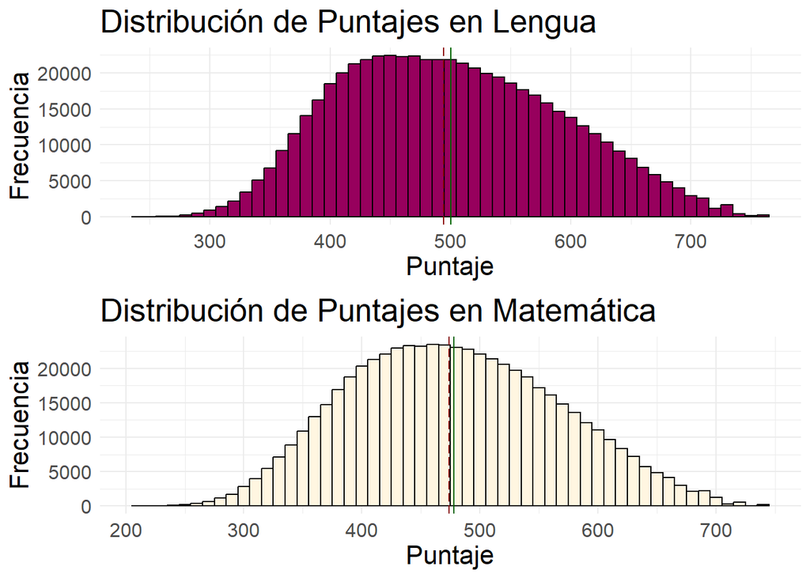

```r
# Histogramas para puntajes

# Histograma de Lengua
hist_lengua <- ggplot(aprender, aes(x = lpuntaje)) +
  geom_histogram(binwidth = 10, fill = "#97005d", color = "black") +
  geom_vline(aes(xintercept = mean(lpuntaje, na.rm = TRUE)), color = "darkgreen", linetype = "solid") + # Línea para la media
  geom_vline(aes(xintercept = median(lpuntaje, na.rm = TRUE)), color = "darkred", linetype = "longdash") + # Línea para la mediana
  labs(title = "Distribución de Puntajes en Lengua", x = "Puntaje", y = "Frecuencia") +
  theme_minimal() +
  scale_x_continuous(breaks = seq(0, max(aprender$lpuntaje, na.rm = TRUE), by = 100)) +
  theme(
    plot.title = element_text(size = 20),
    axis.title = element_text(size = 16),
    axis.text = element_text(size = 12)
  )

# Histograma de Matemática
hist_matematica <- ggplot(aprender, aes(x = mpuntaje)) +
  geom_histogram(binwidth = 10, fill = "#fff6e1", color = "black") +
  geom_vline(aes(xintercept = mean(mpuntaje, na.rm = TRUE)), color = "darkgreen", linetype = "solid") + # Línea para la media
  geom_vline(aes(xintercept = median(mpuntaje, na.rm = TRUE)), color = "darkred", linetype = "longdash") + # Línea para la mediana
  labs(title = "Distribución de Puntajes en Matemática", x = "Puntaje", y = "Frecuencia") +
  theme_minimal() +
  scale_x_continuous(breaks = seq(0, max(aprender$mpuntaje, na.rm = TRUE), by = 100)) +
  theme(
    plot.title = element_text(size = 20),
    axis.title = element_text(size = 16),
    axis.text = element_text(size = 12)
  )
# Mostrar gráficos en una ventana grande
library(gridExtra)
grid.arrange(hist_lengua, hist_matematica, ncol = 1)
```

```r
# Frecuencia y proporciones para ver cuántos registros son por provincia y region

region <- aprender %>%
  count(region) %>%
  mutate(porcentaje = round((n / sum(n)) * 100, 1))

provincias <- aprender %>%
  count(jurisdiccion) %>%
  mutate(porcentaje = round((n / sum(n)) * 100, 1))

kable(region, caption = "Registros por Region") %>%
  kable_styling(bootstrap_options = c("striped", "hover", "condensed", "responsive")) %>%
  column_spec(1, bold = TRUE) %>%
  kable_classic(full_width = F, html_font = "Arial")
```

Registros por Region

| region | n | porcentaje |
| --- | --- | --- |
| CENTRO | 355853 | 62.5 |
| CUYO | 45326 | 8.0 |
| NEA | 58062 | 10.2 |
| NOA | 80928 | 14.2 |
| SUR | 29343 | 5.2 |

```r
kable(provincias, caption = "Registros por provincia") %>%
  kable_styling(bootstrap_options = c("striped", "hover", "condensed", "responsive")) %>%
  column_spec(1, bold = TRUE) %>%
  kable_classic(full_width = F, html_font = "Arial")
```

Registros por provincia

| jurisdiccion | n | porcentaje |
| --- | --- | --- |
| Ciudad Autónoma de Buenos Aires | 29036 | 5.1 |
| Buenos Aires | 216699 | 38.0 |
| Catamarca | 5520 | 1.0 |
| Córdoba | 50429 | 8.9 |
| Corrientes | 16083 | 2.8 |
| Chaco | 15623 | 2.7 |
| Chubut | 6550 | 1.2 |
| Entre Ríos | 17856 | 3.1 |
| Formosa | 9274 | 1.6 |
| Jujuy | 10964 | 1.9 |
| La Pampa | 4606 | 0.8 |
| La Rioja | 5683 | 1.0 |
| Mendoza | 26245 | 4.6 |
| Misiones | 17082 | 3.0 |
| Neuquén | 2563 | 0.5 |
| Río Negro | 9358 | 1.6 |
| Salta | 21658 | 3.8 |
| San Juan | 12180 | 2.1 |
| San Luis | 6901 | 1.2 |
| Santa Cruz | 4240 | 0.7 |
| Santa Fe | 41833 | 7.3 |
| Santiago del Estero | 14827 | 2.6 |
| Tucumán | 22276 | 3.9 |
| Tierra del Fuego, Antártida e Islas del Atlántico Sur | 2026 | 0.4 |

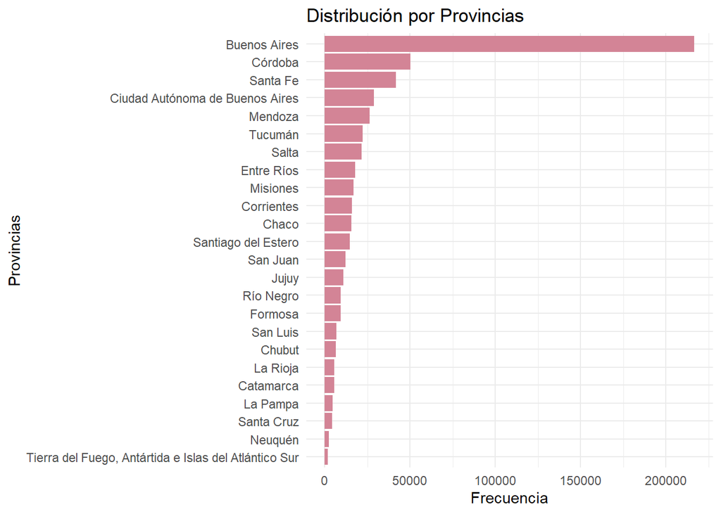

```r
# Gráfico de barras
(plot <- ggplot(provincias, aes(x = reorder(jurisdiccion, n), y = n)) +
  geom_bar(stat = "identity", fill = "#d38496") +
  coord_flip() +
  labs(title = "Distribución por Provincias", x = "Provincias", y = "Frecuencia")+
  theme(
    plot.title = element_text(size = 20),
    axis.title = element_text(size = 16),
    axis.text = element_text(size = 12)
  ) +
  theme_minimal())
```

```r
# save plot
ggsave("plot.png", plot, width = 10, height = 6, units = "in")
```

En general, los estudiantes parecen tener un rendimiento algo mejor en Lengua (media más alta) que en Matemática.

```r
# Tabla de frecuencias para el Nivel Socioeconómico
tabla_nse <- aprender %>%
  count(NSE_nivel) %>%
  mutate(porcentaje = round((n / sum(n)) * 100, 1))

print(tabla_nse)
```

```
## # A tibble: 3 × 3
##   NSE_nivel      n porcentaje
##   <fct>      <int>      <dbl>
## 1 Bajo       49077        8.6
## 2 Medio     435625       76.5
## 3 Alto       84810       14.9
```

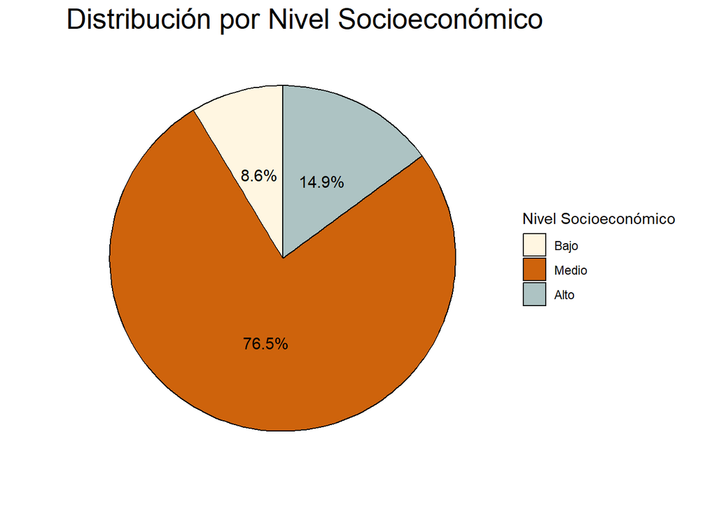

```r
# NSE_Nivel sea una variable categórica.
tabla_nse$NSE_nivel <- as.factor(tabla_nse$NSE_nivel)

ggplot(tabla_nse, aes(x = "", y = n, fill = NSE_nivel)) +
  geom_bar(stat = "identity", width = 1, color = "black") +  # Añadir bordes a las divisiones
  coord_polar(theta = "y") +
  geom_text(aes(label = paste0(porcentaje, "%")),
            position = position_stack(vjust = 0.5),
            size = 4,
            color = "black") +
  labs(title = "Distribución por Nivel Socioeconómico", x = "", y = "") +
  scale_fill_manual(values = tail(paleta_categoria,3)) +
  theme_minimal() +
  theme(
    plot.title = element_text(size = 20),
    axis.title = element_text(size = 16),
    axis.text.x = element_blank(),
    axis.ticks = element_blank(),
    panel.grid = element_blank(), # Eliminar cuadrícula
    panel.background = element_blank(), # Fondo transparente
    plot.background = element_blank()   # Fondo transparente
  ) +
  guides(fill = guide_legend(title = "Nivel Socioeconómico"))
```

```r
summary(aprender)
```

```
##  cod_establecimiento    region
##  Length:569512       Length:569512
##  Class :character    Class :character
##  Mode  :character    Mode  :character
##
##
##
##
##                           jurisdiccion       ambito           sector
##  Buenos Aires                   :216699   Rural : 56450   Estatal:404173
##  Córdoba                        : 50429   Urbano:513062   Privado:165339
##  Santa Fe                       : 41833
##  Ciudad Autónoma de Buenos Aires: 29036
##  Mendoza                        : 26245
##  Tucumán                        : 22276
##  (Other)                        :182994
##               edad            mes                   sexo
##  10 años o menos:  1527   Length:569512      Masculino:282131
##  11 años        :394026   Class :character   Femenino :282696
##  12 años        :158958   Mode  :character   X        :  4685
##  13 años        : 12210
##  14 años o más  :  2791
##
##
##     pais_origen        lpondera         mpondera
##  Argentina:555942   Min.   : 1.000   Min.   : 1.000
##  Bolivia  :  2327   1st Qu.: 1.064   1st Qu.: 1.070
##  Paraguay :  2182   Median : 1.143   Median : 1.152
##  Venezuela:  2144   Mean   : 1.234   Mean   : 1.252
##  Brasil   :  1230   3rd Qu.: 1.273   3rd Qu.: 1.296
##  Otro     :  1159   Max.   :21.490   Max.   :22.133
##  (Other)  :  4528
##                         ldesemp          lpuntaje
##  Por debajo del nivel básico: 62721   Min.   :244.2
##  Básico                     :117617   1st Qu.:429.9
##  Satisfactorio              :214691   Median :494.2
##  Avanzado                   :174483   Mean   :500.3
##                                       3rd Qu.:565.7
##                                       Max.   :757.9
##
```

[output cut: 17 more lines]

```
##  No fue a la escuela                        :  9515   Min.   :  245.0
##  Primaria incompleta                        : 61742   1st Qu.:  501.7
##  Primaria completa                          : 42967   Median :  583.4
##  Secundaria incompleta                      :115150   Mean   :  614.6
##  Secundaria completa                        :155827   3rd Qu.:  679.3
##  Terciario/universitario/posgrado incompleto: 33375   Max.   :14404.7
##  Terciario/universitario/posgrado completo  :150936
##  mpuntaje_pond
##  Min.   :  216.4
##  1st Qu.:  483.9
##  Median :  563.8
##  Mean   :  596.0
##  3rd Qu.:  657.8
##  Max.   :13706.8
##
```

```r
puntajes <- aprender[, c("lpuntaje","mpuntaje")]


# Ajustar opciones globales para evitar notación científica
options(scipen = 999)

minimos <- round(apply(puntajes, 2, min, na.rm = TRUE), 2)
maximos <- round(apply(puntajes, 2, max, na.rm = TRUE), 2)
medias <- round(colMeans(puntajes, na.rm = TRUE), 2)
medianas <- round(apply(puntajes, 2, median, na.rm = TRUE), 2)
varianzas <- round(apply(puntajes, 2, var, na.rm = TRUE), 2)
desviaciones_estandar <- round(apply(puntajes, 2, sd, na.rm = TRUE), 2)
coeficientes_de_variacion <- round(desviaciones_estandar / medias, 2)
cuartiles_1 <- round(apply(puntajes, 2, quantile, probs = 0.25, na.rm = TRUE), 2)
cuartiles_3 <- round(apply(puntajes, 2, quantile, probs = 0.75, na.rm = TRUE), 2)
rango_intercuartilico <- round(cuartiles_3 - cuartiles_1, 2)

# Crear tabla con medidas descriptivas
tabla_descriptiva <- data.frame(
  n = colSums(!is.na(puntajes)),
  Minimo = minimos,
  Maximo = maximos,
  Media = medias,
  Mediana = medianas,
  Varianza = varianzas,
  "Desv_Estandar" = desviaciones_estandar,
  "Coef_Variacion" = coeficientes_de_variacion,
  "Cuartil 1" = cuartiles_1,
  "Cuartil 3" = cuartiles_3,
  "Rango_Intercuartilico" = rango_intercuartilico
)

# Mostrar tabla con formato
kable(tabla_descriptiva, caption = "Tabla Descriptiva de Medidas Estadísticas de los Puntajes de los estudiantes") %>%
  kable_styling(bootstrap_options = c("striped", "hover", "condensed", "responsive")) %>%
  column_spec(1, bold = TRUE) %>%
  kable_classic(full_width = F, html_font = "Arial")
```

Tabla Descriptiva de Medidas Estadísticas de los Puntajes de los estudiantes

|  | n | Minimo | Maximo | Media | Mediana | Varianza | Desv_Estandar | Coef_Variacion | Cuartil.1 | Cuartil.3 | Rango_Intercuartilico |
| --- | --- | --- | --- | --- | --- | --- | --- | --- | --- | --- | --- |
| lpuntaje | 569512 | 244.15 | 757.93 | 500.29 | 494.23 | 8246.05 | 90.81 | 0.18 | 429.93 | 565.74 | 135.81 |
| mpuntaje | 569512 | 212.01 | 739.70 | 478.13 | 474.10 | 7707.52 | 87.79 | 0.18 | 412.31 | 540.63 | 128.32 |

- Varianza y Desviación Estándar:

- Coeficiente de Variación (CV):

Ambos tienen un coeficiente de variación bajo (0.18 en ambos casos), lo que indica que la dispersión relativa es pequeña en comparación con las medias respectivas. Esto sugiere que los puntajes son bastante consistentes entre los estudiantes.

- Rangos generales:

En Lengua, los puntajes van de 244.15 a 757.93, mientras que en Matemática van de 212.01 a 739.70. Significa que hay mayor presencia de notas bajas en matemática.

- Cuartiles:

```r
# Correlación entre puntajes
correlacion_puntajes <- cor(puntajes , use = "pairwise.complete.obs")
correlacion_puntajes
```

```
##           lpuntaje  mpuntaje
## lpuntaje 1.0000000 0.6163042
## mpuntaje 0.6163042 1.0000000
```

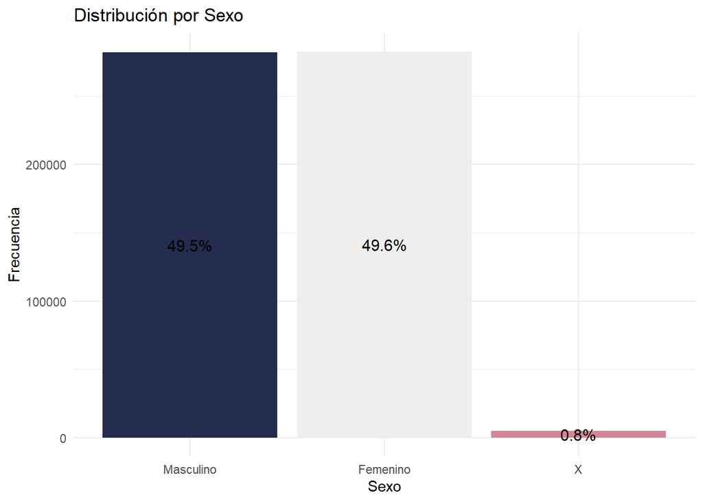

```r
# Distribucion de variables sexo, edad, ambito, sector

# Sexo
sexo <- aprender %>%
  count(sexo) %>%
  mutate(porcentaje = round((n / sum(n)) * 100, 1))

# Edad
edad <- aprender %>%
  count(edad) %>%
  mutate(porcentaje = round((n / sum(n)) * 100, 1))

# Ambito
ambito <- aprender %>%
  count(ambito) %>%
  mutate(porcentaje = round((n / sum(n)) * 100, 1))

# Sector
sector <- aprender %>%
  count(sector) %>%
  mutate(porcentaje = round((n / sum(n)) * 100, 1))

# Crear gráficos de barras
sexo_plot <- ggplot(sexo, aes(x = sexo, y = n, fill = sexo)) +
  geom_bar(stat = "identity") +
  geom_text(aes(label = paste0(porcentaje, "%")),
            position = position_stack(vjust = 0.5),
            size = 4,
            color = "black") +
  labs(title = "Distribución por Sexo", x = "Sexo", y = "Frecuencia") +
  scale_fill_manual(values = c("#242c4f", "#efeeed", "#d38496", "#97005d", "#fff6e1")) +
  theme_minimal() +
  theme(legend.position = "none")

edad_plot <- ggplot(edad, aes(x = edad, y = n, fill = edad)) +
  geom_bar(stat = "identity") +
  geom_text(aes(label = paste0(porcentaje, "%")),
            position = position_stack(vjust = 0.5),
            size = 4,
            color = "black") +
  labs(title = "Distribución por Edad", x = "Edad", y = "Frecuencia") +
  scale_fill_manual(values = c("#242c4f", "#efeeed", "#d38496", "#97005d", "#fff6e1")) +
  theme_minimal() +
  theme(legend.position = "none", axis.text.x = element_text(angle = 45, hjust = 1))

ambito_plot <- ggplot(ambito, aes(x = ambito, y = n, fill = ambito)) +
  geom_bar(stat = "identity") +
  geom_text(aes(label = paste0(porcentaje, "%")),
            position = position_stack(vjust = 0.5),
            size = 4,
            color = "black") +
  labs(title = "Distribución por Ámbito", x = "Ámbito", y = "Frecuencia") +
  scale_fill_manual(values = c("#242c4f", "#efeeed", "#d38496", "#97005d", "#fff6e1")) +
  theme_minimal() +
  theme(legend.position = "none")

sector_plot <- ggplot(sector, aes(x = sector, y = n, fill = sector)) +
  geom_bar(stat = "identity") +
  geom_text(aes(label = paste0(porcentaje, "%")),
            position = position_stack(vjust = 0.5),
            size = 4,
            color = "black") +
  labs(title = "Distribución por Sector", x = "Sector", y = "Frecuencia") +
  scale_fill_manual(values = c("#242c4f", "#efeeed", "#d38496", "#97005d", "#fff6e1")) +
  theme_minimal() +
  theme(legend.position = "none")

# Mostrar gráficos en una ventana grande
sexo_plot
```

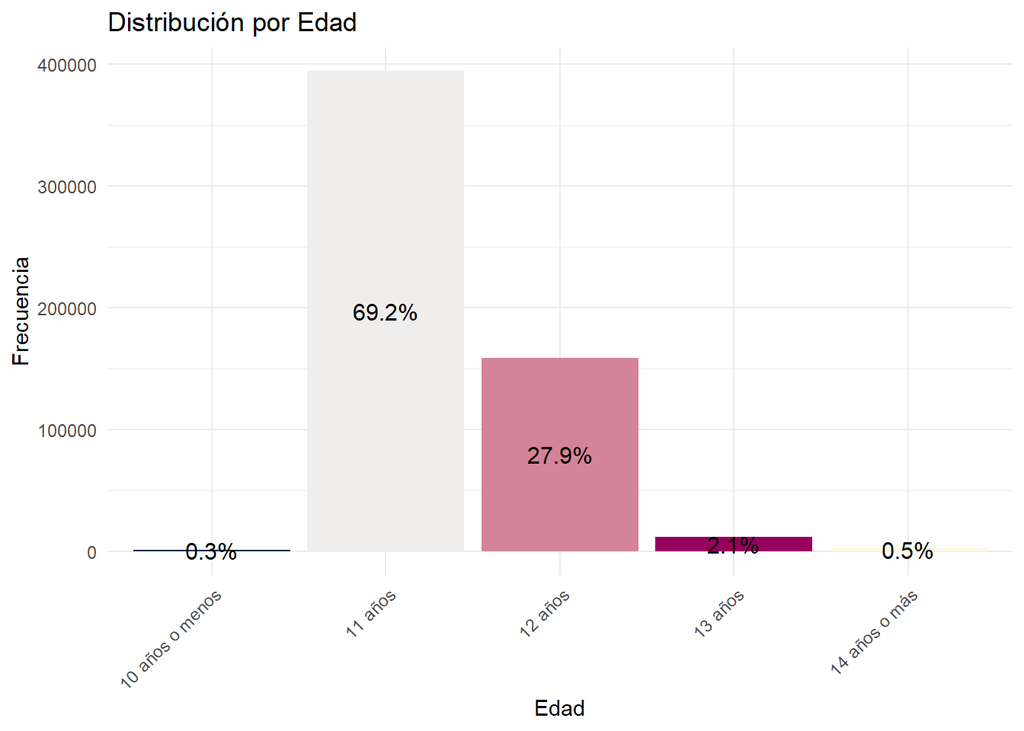

```r
edad_plot
```

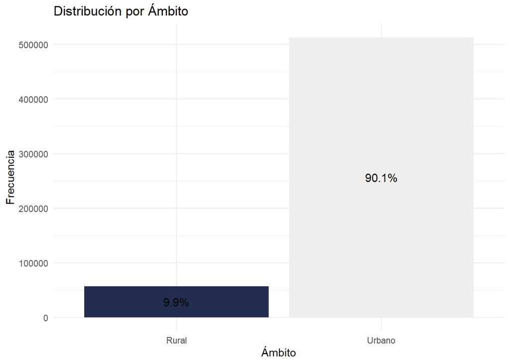

```r
ambito_plot
```

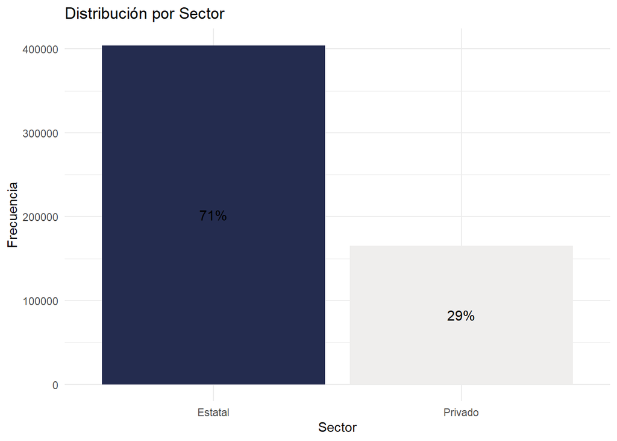

```r
sector_plot
```

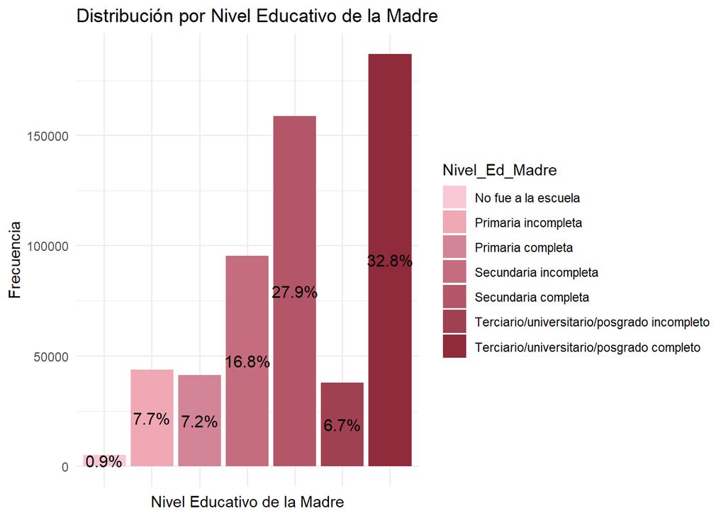

```r
color_Vec <- c("#f8c8d4", "#f0a8b5", "#d38496", "#c56d7e", "#b35768", "#a04151", "#8f2b3b")

# Distribucion por Nivel Educativo de la Madre
nivel_ed_madre <- aprender %>%
  count(Nivel_Ed_Madre) %>%
  mutate(porcentaje = round((n / sum(n)) * 100, 1))

# Distribucion por Nivel Educativo del Padre
nivel_ed_padre <- aprender %>%
  count(Nivel_Ed_Padre) %>%
  mutate(porcentaje = round((n / sum(n)) * 100, 1))

# Crear gráficos de barras
nivel_ed_madre_plot <- ggplot(nivel_ed_madre, aes(x = Nivel_Ed_Madre, y = n, fill = Nivel_Ed_Madre)) +
  geom_bar(stat = "identity") +
  geom_text(aes(label = paste0(porcentaje, "%")),
            position = position_stack(vjust = 0.5),
            size = 4,
            color = "black") +
  labs(title = "Distribución por Nivel Educativo de la Madre", x = "Nivel Educativo de la Madre", y = "Frecuencia") +
  scale_fill_manual(values = color_Vec) +
  theme_minimal() +
  theme(axis.text.x = element_blank())

nivel_ed_padre_plot <- ggplot(nivel_ed_padre, aes(x = Nivel_Ed_Padre, y = n, fill = Nivel_Ed_Padre)) +
  geom_bar(stat = "identity") +
  geom_text(aes(label = paste0(porcentaje, "%")),
            position = position_stack(vjust = 0.5),
            size = 4,
            color = "black") +
  labs(title = "Distribución por Nivel Educativo del Padre", x = "Nivel Educativo del Padre", y = "Frecuencia") +
  scale_fill_manual(values = color_Vec) +
  theme_minimal() +
  theme(axis.text.x = element_blank(), legend.position = "none")

# Mostrar gráficos en una ventana grande
nivel_ed_madre_plot
```

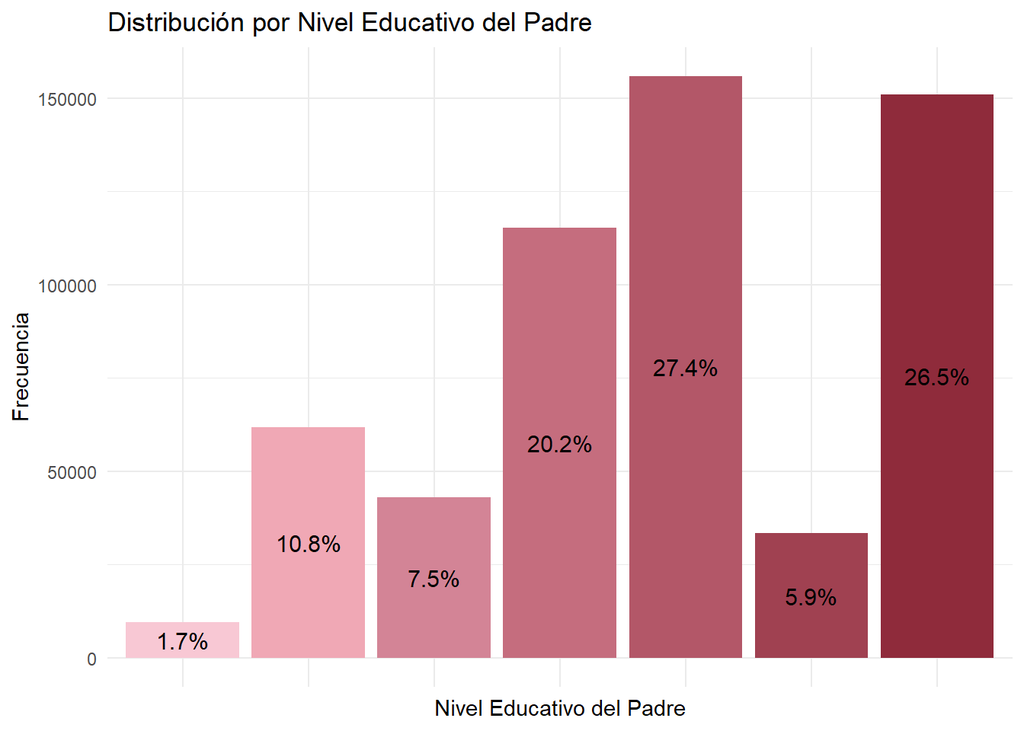

```r
nivel_ed_padre_plot
```

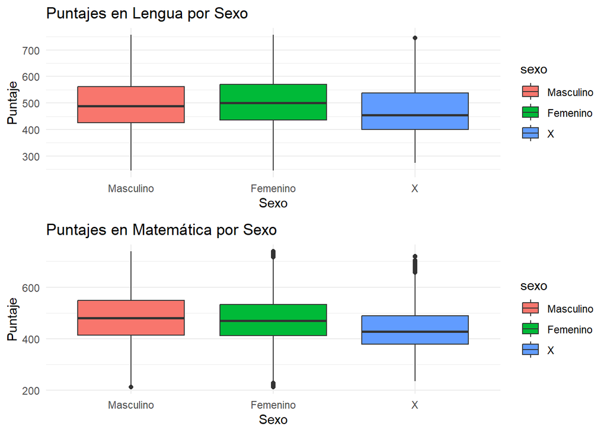

```r
# Boxplot de puntajes por sexo
boxplot_lengua <- ggplot(aprender, aes(x = sexo, y = lpuntaje, fill = sexo)) +
  geom_boxplot() +
  labs(title = "Puntajes en Lengua por Sexo", x = "Sexo", y = "Puntaje") +
  theme_minimal()

boxplot_matematica <- ggplot(aprender, aes(x = sexo, y = mpuntaje, fill = sexo)) +
  geom_boxplot() +
  labs(title = "Puntajes en Matemática por Sexo", x = "Sexo", y = "Puntaje") +
  theme_minimal()

# Mostrar gráficos en una ventana grande
grid.arrange(boxplot_lengua, boxplot_matematica, ncol = 1)
```

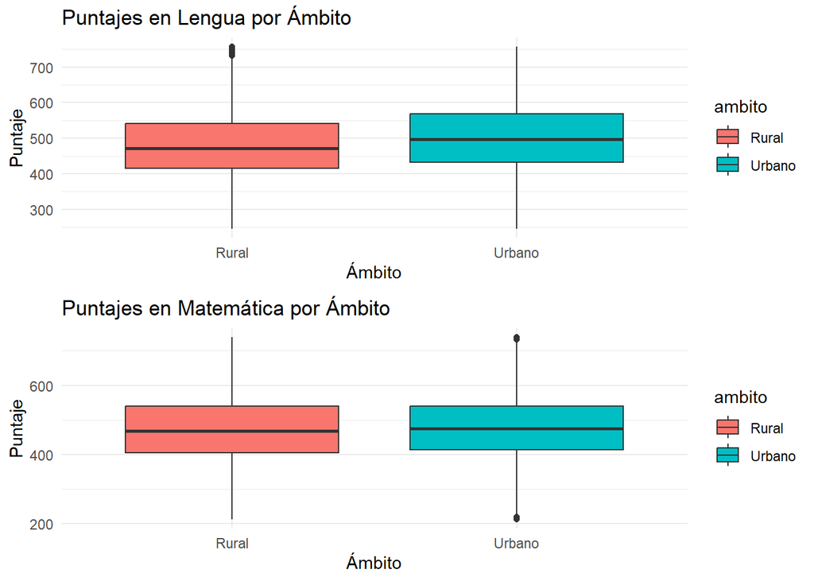

```r
# Boxplot de puntajes por ámbito
boxplot_lengua <- ggplot(aprender, aes(x = ambito, y = lpuntaje, fill = ambito)) +
  geom_boxplot() +
  labs(title = "Puntajes en Lengua por Ámbito", x = "Ámbito", y = "Puntaje") +
  theme_minimal()

boxplot_matematica <- ggplot(aprender, aes(x = ambito, y = mpuntaje, fill = ambito)) +
  geom_boxplot() +
  labs(title = "Puntajes en Matemática por Ámbito", x = "Ámbito", y = "Puntaje") +
  theme_minimal()

# Mostrar gráficos en una ventana grande
grid.arrange(boxplot_lengua, boxplot_matematica, ncol = 1)
```

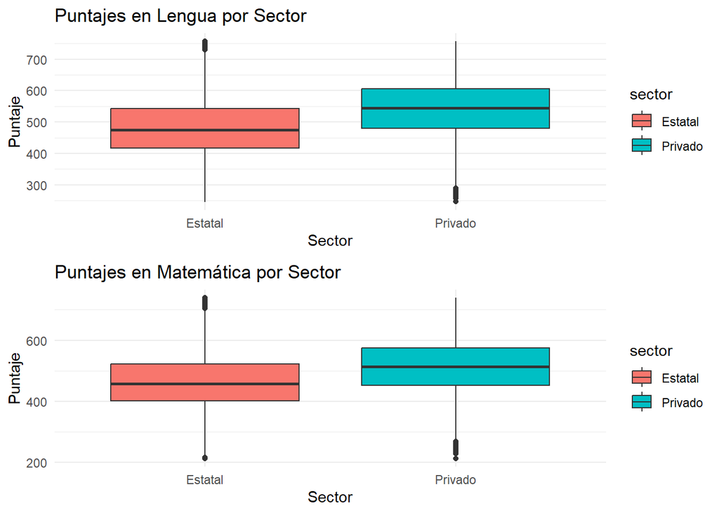

```r
# Boxplot de puntajes por sector
boxplot_lengua <- ggplot(aprender, aes(x = sector, y = lpuntaje, fill = sector)) +
  geom_boxplot() +
  labs(title = "Puntajes en Lengua por Sector", x = "Sector", y = "Puntaje") +
  theme_minimal()

boxplot_matematica <- ggplot(aprender, aes(x = sector, y = mpuntaje, fill = sector)) +
  geom_boxplot() +
  labs(title = "Puntajes en Matemática por Sector", x = "Sector", y = "Puntaje") +
  theme_minimal()

# Mostrar gráficos en una ventana grande
grid.arrange(boxplot_lengua, boxplot_matematica, ncol = 1)
```

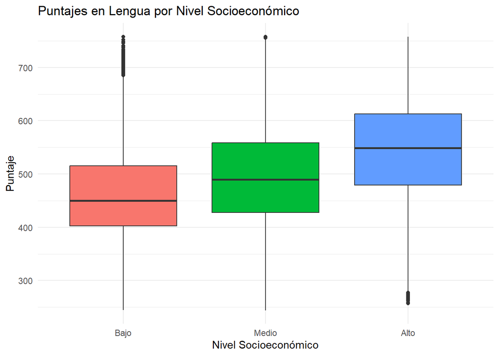

```r
# Boxplot de puntajes por nivel socioeconómico
boxplot_lengua <- ggplot(aprender, aes(x = NSE_nivel, y = lpuntaje, fill = NSE_nivel)) +
  geom_boxplot() +
  labs(title = "Puntajes en Lengua por Nivel Socioeconómico", x = "Nivel Socioeconómico", y = "Puntaje") +
  theme_minimal() +
  theme(legend.position = "none")

boxplot_matematica <- ggplot(aprender, aes(x = NSE_nivel, y = mpuntaje, fill = NSE_nivel)) +
  geom_boxplot() +
  labs(title = "Puntajes en Matemática por Nivel Socioeconómico", x = "Nivel Socioeconómico", y = "Puntaje") +
  theme_minimal()

boxplot_lengua
```

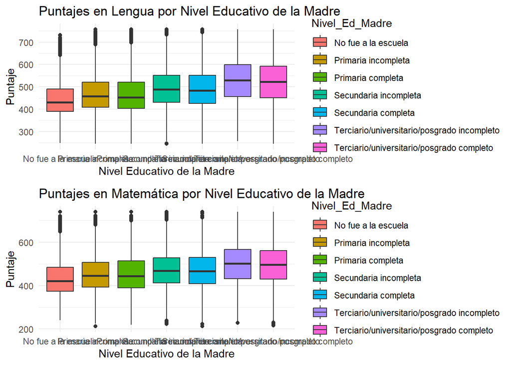

```r
# Boxplot de puntajes por nivel educativo de la madre
boxplot_lengua <- ggplot(aprender, aes(x = Nivel_Ed_Madre, y = lpuntaje, fill = Nivel_Ed_Madre)) +
  geom_boxplot() +
  labs(title = "Puntajes en Lengua por Nivel Educativo de la Madre", x = "Nivel Educativo de la Madre", y = "Puntaje") +
  theme_minimal()

boxplot_matematica <- ggplot(aprender, aes(x = Nivel_Ed_Madre, y = mpuntaje, fill = Nivel_Ed_Madre)) +
  geom_boxplot() +
  labs(title = "Puntajes en Matemática por Nivel Educativo de la Madre", x = "Nivel Educativo de la Madre", y = "Puntaje") +
  theme_minimal()

# Mostrar gráficos en una ventana grande
grid.arrange(boxplot_lengua, boxplot_matematica, ncol = 1)
```

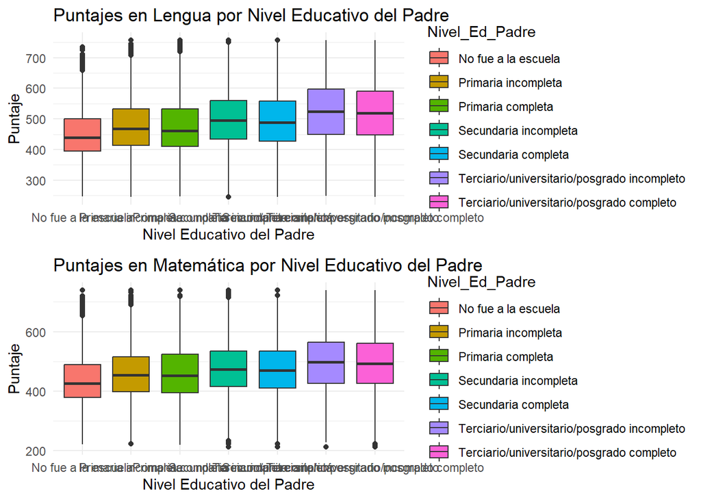

```r
# Boxplot de puntajes por nivel educativo del padre
boxplot_lengua <- ggplot(aprender, aes(x = Nivel_Ed_Padre, y = lpuntaje, fill = Nivel_Ed_Padre)) +
  geom_boxplot() +
  labs(title = "Puntajes en Lengua por Nivel Educativo del Padre", x = "Nivel Educativo del Padre", y = "Puntaje") +
  theme_minimal()

boxplot_matematica <- ggplot(aprender, aes(x = Nivel_Ed_Padre, y = mpuntaje, fill = Nivel_Ed_Padre)) +
  geom_boxplot() +
  labs(title = "Puntajes en Matemática por Nivel Educativo del Padre", x = "Nivel Educativo del Padre", y = "Puntaje") +
  theme_minimal()

# Mostrar gráficos en una ventana grande
grid.arrange(boxplot_lengua, boxplot_matematica, ncol = 1)
```

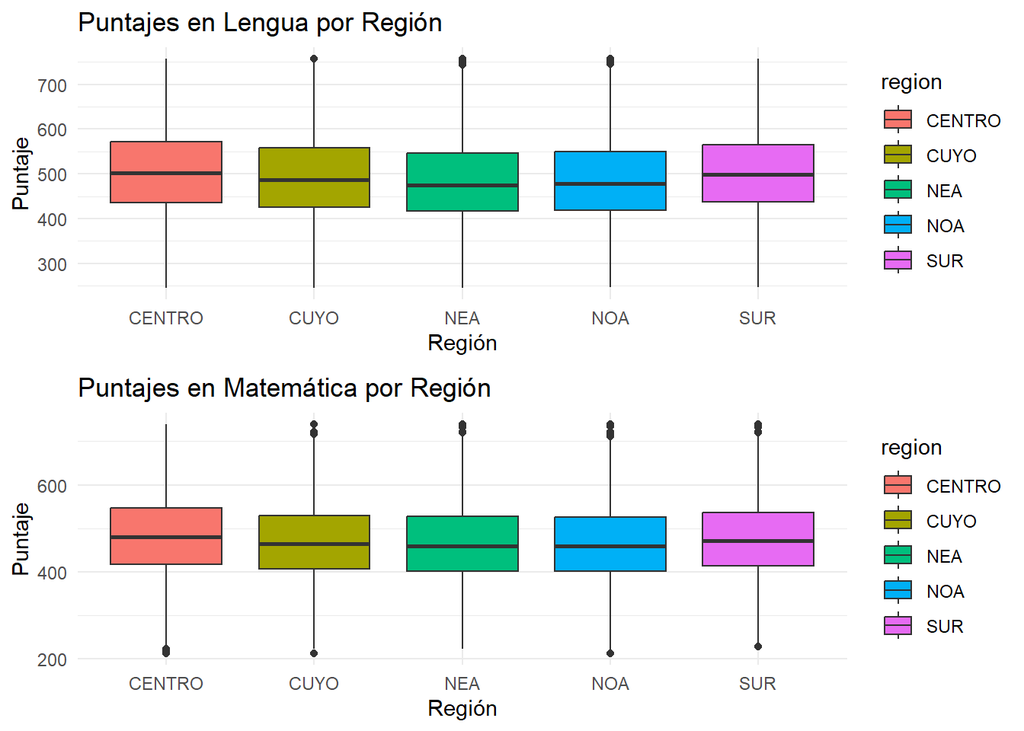

```r
# Boxplot de puntajes por región
boxplot_lengua <- ggplot(aprender, aes(x = region, y = lpuntaje, fill = region)) +
  geom_boxplot() +
  labs(title = "Puntajes en Lengua por Región", x = "Región", y = "Puntaje") +
  theme_minimal()

boxplot_matematica <- ggplot(aprender, aes(x = region, y = mpuntaje, fill = region)) +
  geom_boxplot() +
  labs(title = "Puntajes en Matemática por Región", x = "Región", y = "Puntaje") +
  theme_minimal()

# Mostrar gráficos en una ventana grande
grid.arrange(boxplot_lengua, boxplot_matematica, ncol = 1)
```

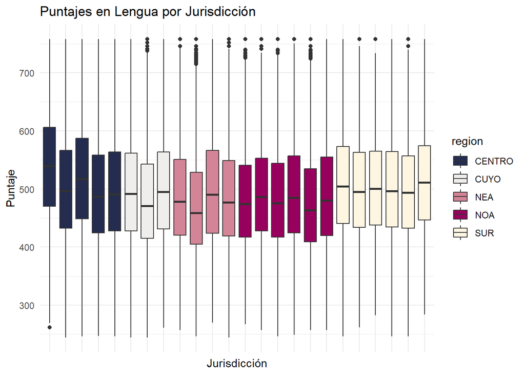

```r
library(forcats)

# Boxplot de puntajes por jurisdicción, sin etiquetas eje x ni leyendas, colorear y ordenar por region
boxplot_lengua <- ggplot(aprender, aes(x = fct_reorder(jurisdiccion, desc(desc(region))), y = lpuntaje, fill = region)) +
  geom_boxplot() +
  labs(title = "Puntajes en Lengua por Jurisdicción", x = "Jurisdicción", y = "Puntaje") +
  theme_minimal() +
  theme(axis.text.x = element_blank()) +
  scale_fill_manual(values = c("#242c4f", "#efeeed", "#d38496", "#97005d", "#fff6e1"))

boxplot_matematica <- ggplot(aprender, aes(x = fct_reorder(jurisdiccion, desc(desc(region))), y = mpuntaje, fill = region)) +
  geom_boxplot() +
  labs(title = "Puntajes en Matemática por Jurisdicción", x = "Jurisdicción", y = "Puntaje") +
  theme_minimal() +
  theme(axis.text.x = element_blank(), axis.title.x = element_blank())

boxplot_lengua
```

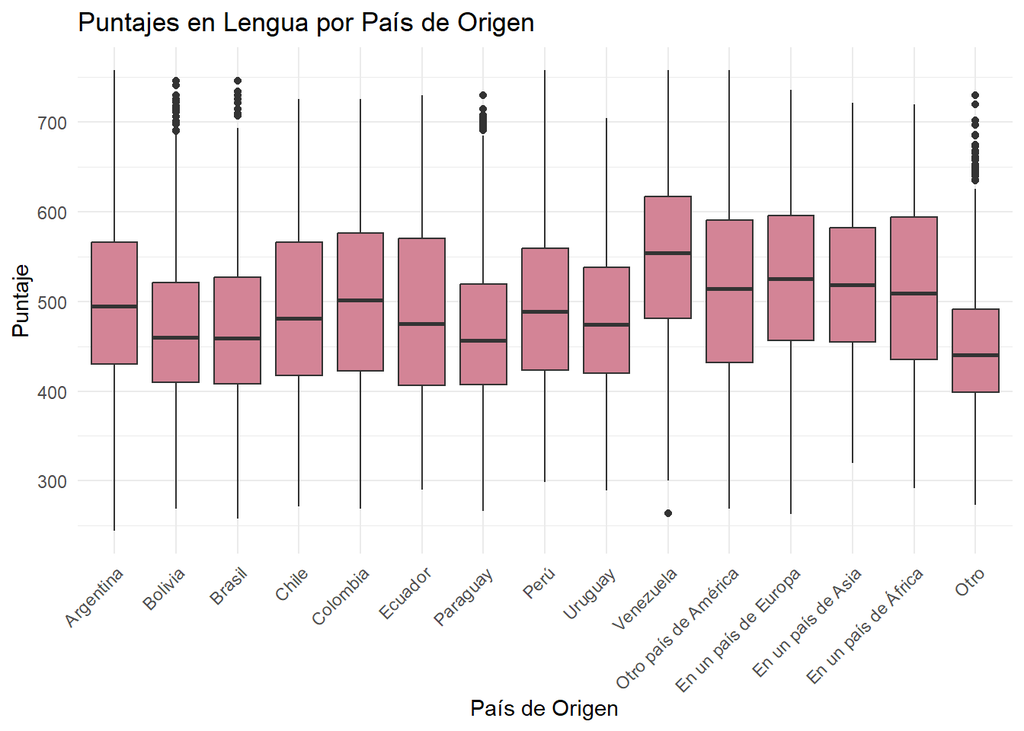

```r
# Boxplot de puntajes por país de origen
boxplot_lengua <- ggplot(aprender, aes(x = pais_origen, y = lpuntaje, fill = head(paleta_categoria, 1))) +
  geom_boxplot() +
  labs(title = "Puntajes en Lengua por País de Origen", x = "País de Origen", y = "Puntaje") +
  theme_minimal() +
  theme(axis.text.x = element_text(angle = 45, hjust = 1), legend.position = "none") +
  scale_fill_manual(values = "#d38496")

boxplot_matematica <- ggplot(aprender, aes(x = pais_origen, y = mpuntaje, fill = pais_origen)) +
  geom_boxplot() +
  labs(title = "Puntajes en Matemática por País de Origen", x = "País de Origen", y = "Puntaje") +
  theme_minimal()

# Mostrar gráficos en una ventana grande
boxplot_lengua
```

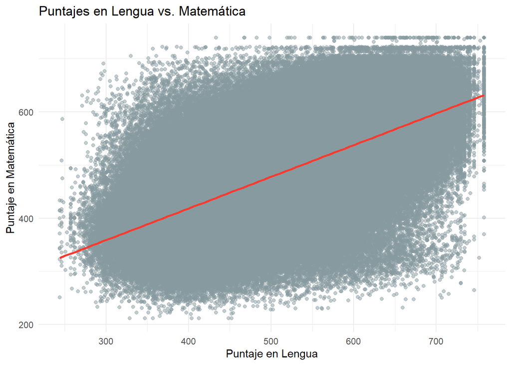

```r
# Scatterplot de puntajes en Lengua y Matemática
scatterplot <- ggplot(aprender, aes(x = lpuntaje, y = mpuntaje)) +
  geom_point(alpha = 0.5, color = paleta_categoria[2]) +
  geom_smooth(method = "lm", se = FALSE, color = paleta_categoria[1]) +
  labs(title = "Puntajes en Lengua vs. Matemática", x = "Puntaje en Lengua", y = "Puntaje en Matemática") +
  theme_minimal()

scatterplot
```

# Modelo Lineal Múltiple

Realizaremos un modelo base para el puntaje en Lengua, utilizando las variables NSE_nivel, Nivel_Ed_Madre, Nivel_Ed_Padre como predictores.

El modelo lineal es:

$$Puntaje = \beta_0 + \beta_1NSE\_nivel +
\beta_2Nivel\_Ed\_Madre + \beta_3Nivel\_Ed\_Padre + \epsilon$$

```r
# Modelo lineal para puntaje en Lengua
modelo_lengua <- lm(lpuntaje ~ NSE_nivel + Nivel_Ed_Madre + Nivel_Ed_Padre,
                    data = aprender,
                    weights = sqrt(aprender$lpondera))

# Resumen del modelo
summary(modelo_lengua)
```

```
##
## Call:
## lm(formula = lpuntaje ~ NSE_nivel + Nivel_Ed_Madre + Nivel_Ed_Padre,
##     data = aprender, weights = sqrt(aprender$lpondera))
##
## Weighted Residuals:
##     Min      1Q  Median      3Q     Max
## -419.11  -67.79   -4.56   65.27  435.13
##
## Coefficients:
##                                                           Estimate Std. Error
## (Intercept)                                               420.3894     1.3595
## NSE_nivelMedio                                             15.0726     0.4447
## NSE_nivelAlto                                              49.4775     0.6004
## Nivel_Ed_MadrePrimaria incompleta                          14.5351     1.2943
## Nivel_Ed_MadrePrimaria completa                            12.4082     1.3060
## Nivel_Ed_MadreSecundaria incompleta                        30.7151     1.2701
## Nivel_Ed_MadreSecundaria completa                          28.5751     1.2567
## Nivel_Ed_MadreTerciario/universitario/posgrado incompleto  55.3905     1.3311
## Nivel_Ed_MadreTerciario/universitario/posgrado completo    45.2014     1.2658
## Nivel_Ed_PadrePrimaria incompleta                          18.2124     0.9779
## Nivel_Ed_PadrePrimaria completa                            20.7375     1.0152
## Nivel_Ed_PadreSecundaria incompleta                        30.1974     0.9599
## Nivel_Ed_PadreSecundaria completa                          27.3319     0.9499
## Nivel_Ed_PadreTerciario/universitario/posgrado incompleto  35.1947     1.0611
## Nivel_Ed_PadreTerciario/universitario/posgrado completo    28.0548     0.9689
##                                                           t value
## (Intercept)                                               309.228
## NSE_nivelMedio                                             33.892
## NSE_nivelAlto                                              82.412
## Nivel_Ed_MadrePrimaria incompleta                          11.231
## Nivel_Ed_MadrePrimaria completa                             9.501
## Nivel_Ed_MadreSecundaria incompleta                        24.184
## Nivel_Ed_MadreSecundaria completa                          22.739
## Nivel_Ed_MadreTerciario/universitario/posgrado incompleto  41.612
## Nivel_Ed_MadreTerciario/universitario/posgrado completo    35.709
## Nivel_Ed_PadrePrimaria incompleta                          18.623
## Nivel_Ed_PadrePrimaria completa                            20.427
## Nivel_Ed_PadreSecundaria incompleta                        31.458
## Nivel_Ed_PadreSecundaria completa                          28.773
```

[output cut: 25 more lines]

```
## Nivel_Ed_MadreSecundaria completa                         ***
## Nivel_Ed_MadreTerciario/universitario/posgrado incompleto ***
## Nivel_Ed_MadreTerciario/universitario/posgrado completo   ***
## Nivel_Ed_PadrePrimaria incompleta                         ***
## Nivel_Ed_PadrePrimaria completa                           ***
## Nivel_Ed_PadreSecundaria incompleta                       ***
## Nivel_Ed_PadreSecundaria completa                         ***
## Nivel_Ed_PadreTerciario/universitario/posgrado incompleto ***
## Nivel_Ed_PadreTerciario/universitario/posgrado completo   ***
## ---
## Signif. codes:  0 '***' 0.001 '**' 0.01 '*' 0.05 '.' 0.1 ' ' 1
##
## Residual standard error: 91.8 on 569497 degrees of freedom
## Multiple R-squared:  0.07293,    Adjusted R-squared:  0.07291
## F-statistic:  3200 on 14 and 569497 DF,  p-value: < 0.00000000000000022
```

```r
# Visualizamos en una tabla los coeficientes del modelo
library(sjPlot)
tab_model(modelo_lengua, file = "modelo_lengua.html")
```

|  | lpuntaje |  |  |
| --- | --- | --- | --- |
| Predictors | Estimates | CI | p |
| (Intercept) | 420.39 | 417.72 – 423.05 | **<0.001** |
| NSE nivel [Medio] | 15.07 | 14.20 – 15.94 | **<0.001** |
| NSE nivel [Alto] | 49.48 | 48.30 – 50.65 | **<0.001** |
| Nivel Ed Madre [Primaria incompleta] | 14.54 | 12.00 – 17.07 | **<0.001** |
| Nivel Ed Madre [Primaria completa] | 12.41 | 9.85 – 14.97 | **<0.001** |
| Nivel Ed Madre [Secundaria incompleta] | 30.72 | 28.23 – 33.20 | **<0.001** |
| Nivel Ed Madre [Secundaria completa] | 28.58 | 26.11 – 31.04 | **<0.001** |
| Nivel Ed Madre [Terciario/universitario/posgrado incompleto] | 55.39 | 52.78 – 58.00 | **<0.001** |
| Nivel Ed Madre [Terciario/universitario/posgrado completo] | 45.20 | 42.72 – 47.68 | **<0.001** |
| Nivel Ed Padre [Primaria incompleta] | 18.21 | 16.30 – 20.13 | **<0.001** |
| Nivel Ed Padre [Primaria completa] | 20.74 | 18.75 – 22.73 | **<0.001** |
| Nivel Ed Padre [Secundaria incompleta] | 30.20 | 28.32 – 32.08 | **<0.001** |
| Nivel Ed Padre [Secundaria completa] | 27.33 | 25.47 – 29.19 | **<0.001** |
| Nivel Ed Padre [Terciario/universitario/posgrado incompleto] | 35.19 | 33.11 – 37.27 | **<0.001** |
| Nivel Ed Padre [Terciario/universitario/posgrado completo] | 28.05 | 26.16 – 29.95 | **<0.001** |
| Observations | 569512 |  |  |
| R<sup>2</sup> / R<sup>2</sup> adjusted | 0.073 / 0.073 |  |  |

Observamos un modelo con todos coeficientes significativos, pero que no llega a explicar mas que el 7% de la varianza en el puntaje. Probamos incluir ambito y sector.

El modelo es

$$Puntaje = \beta_0 + \beta_1NSE\_nivel +
\beta_2Nivel\_Ed\_Madre + \beta_3Nivel\_Ed\_Padre + \beta_4ambito +
\beta_5sector + \epsilon$$

```r
# Modelo lineal para puntaje en Lengua
modelo_lineal <- lm(lpuntaje ~ NSE_nivel + Nivel_Ed_Madre + Nivel_Ed_Padre + ambito + sector,
                    data = aprender,
                    weights = sqrt(aprender$lpondera))

# Resumen del modelo
summary(modelo_lineal)
```

```
##
## Call:
## lm(formula = lpuntaje ~ NSE_nivel + Nivel_Ed_Madre + Nivel_Ed_Padre +
##     ambito + sector, data = aprender, weights = sqrt(aprender$lpondera))
##
## Weighted Residuals:
##     Min      1Q  Median      3Q     Max
## -358.31  -65.61   -5.12   62.45  447.19
##
## Coefficients:
##                                                           Estimate Std. Error
## (Intercept)                                               426.2170     1.3557
## NSE_nivelMedio                                             10.6920     0.4381
## NSE_nivelAlto                                              32.0460     0.5985
## Nivel_Ed_MadrePrimaria incompleta                          14.5049     1.2640
## Nivel_Ed_MadrePrimaria completa                            12.3787     1.2755
## Nivel_Ed_MadreSecundaria incompleta                        29.4506     1.2406
## Nivel_Ed_MadreSecundaria completa                          25.5332     1.2276
## Nivel_Ed_MadreTerciario/universitario/posgrado incompleto  47.4908     1.3011
## Nivel_Ed_MadreTerciario/universitario/posgrado completo    37.8189     1.2373
## Nivel_Ed_PadrePrimaria incompleta                          16.5718     0.9551
## Nivel_Ed_PadrePrimaria completa                            18.9431     0.9917
## Nivel_Ed_PadreSecundaria incompleta                        26.6158     0.9378
## Nivel_Ed_PadreSecundaria completa                          23.0925     0.9281
## Nivel_Ed_PadreTerciario/universitario/posgrado incompleto  28.7108     1.0372
## Nivel_Ed_PadreTerciario/universitario/posgrado completo    22.6739     0.9469
## ambitoUrbano                                               -5.3794     0.3917
## sectorPrivado                                              45.7046     0.2755
##                                                           t value
## (Intercept)                                               314.388
## NSE_nivelMedio                                             24.403
## NSE_nivelAlto                                              53.547
## Nivel_Ed_MadrePrimaria incompleta                          11.475
## Nivel_Ed_MadrePrimaria completa                             9.705
## Nivel_Ed_MadreSecundaria incompleta                        23.739
## Nivel_Ed_MadreSecundaria completa                          20.800
## Nivel_Ed_MadreTerciario/universitario/posgrado incompleto  36.499
## Nivel_Ed_MadreTerciario/universitario/posgrado completo    30.566
## Nivel_Ed_PadrePrimaria incompleta                          17.350
## Nivel_Ed_PadrePrimaria completa                            19.102
```

[output cut: 33 more lines]

```
## Nivel_Ed_MadreTerciario/universitario/posgrado completo   ***
## Nivel_Ed_PadrePrimaria incompleta                         ***
## Nivel_Ed_PadrePrimaria completa                           ***
## Nivel_Ed_PadreSecundaria incompleta                       ***
## Nivel_Ed_PadreSecundaria completa                         ***
## Nivel_Ed_PadreTerciario/universitario/posgrado incompleto ***
## Nivel_Ed_PadreTerciario/universitario/posgrado completo   ***
## ambitoUrbano                                              ***
## sectorPrivado                                             ***
## ---
## Signif. codes:  0 '***' 0.001 '**' 0.01 '*' 0.05 '.' 0.1 ' ' 1
##
## Residual standard error: 89.66 on 569495 degrees of freedom
## Multiple R-squared:  0.1158, Adjusted R-squared:  0.1158
## F-statistic:  4661 on 16 and 569495 DF,  p-value: < 0.00000000000000022
```

```r
# Visualizamos en una tabla los coeficientes del modelo
tab_model(modelo_lineal, file = "modelo_lineal.html")
```

|  | lpuntaje |  |  |
| --- | --- | --- | --- |
| Predictors | Estimates | CI | p |
| (Intercept) | 426.22 | 423.56 – 428.87 | **<0.001** |
| NSE nivel [Medio] | 10.69 | 9.83 – 11.55 | **<0.001** |
| NSE nivel [Alto] | 32.05 | 30.87 – 33.22 | **<0.001** |
| Nivel Ed Madre [Primaria incompleta] | 14.50 | 12.03 – 16.98 | **<0.001** |
| Nivel Ed Madre [Primaria completa] | 12.38 | 9.88 – 14.88 | **<0.001** |
| Nivel Ed Madre [Secundaria incompleta] | 29.45 | 27.02 – 31.88 | **<0.001** |
| Nivel Ed Madre [Secundaria completa] | 25.53 | 23.13 – 27.94 | **<0.001** |
| Nivel Ed Madre [Terciario/universitario/posgrado incompleto] | 47.49 | 44.94 – 50.04 | **<0.001** |
| Nivel Ed Madre [Terciario/universitario/posgrado completo] | 37.82 | 35.39 – 40.24 | **<0.001** |
| Nivel Ed Padre [Primaria incompleta] | 16.57 | 14.70 – 18.44 | **<0.001** |
| Nivel Ed Padre [Primaria completa] | 18.94 | 17.00 – 20.89 | **<0.001** |
| Nivel Ed Padre [Secundaria incompleta] | 26.62 | 24.78 – 28.45 | **<0.001** |
| Nivel Ed Padre [Secundaria completa] | 23.09 | 21.27 – 24.91 | **<0.001** |
| Nivel Ed Padre [Terciario/universitario/posgrado incompleto] | 28.71 | 26.68 – 30.74 | **<0.001** |
| Nivel Ed Padre [Terciario/universitario/posgrado completo] | 22.67 | 20.82 – 24.53 | **<0.001** |
| ambito [Urbano] | -5.38 | -6.15 – -4.61 | **<0.001** |
| sector [Privado] | 45.70 | 45.16 – 46.24 | **<0.001** |
| Observations | 569512 |  |  |
| R<sup>2</sup> / R<sup>2</sup> adjusted | 0.116 / 0.116 |  |  |

Por un lado, existen muchos factores que influyen en el rendimiento de los estudiantes durante una prueba estandarizada, algo que no podremos incluir necesariamente en nuestro modelo. Pero por otro, y mas relevante para nuestro problema, es que no hay total independencia en las observaciones, ya que los estudiantes están agrupados por escuela, jurisdicción y región. Esto puede llevar a que los errores estén correlacionados, lo que puede afectar la validez de los intervalos de confianza y los tests de hipótesis.

Para esto debemos incluir como efectos aleatorios a estas variables, para controlar la variabilidad.

# Modelo Lineal con Efectos Mixtos

Realizamos un primer modelo, incluyendo país de orígen y escuela/region/jurisdicción como efectos aleatorios con intercepto variable

El modelo es:

$$Puntaje = \beta_0 + \beta_1NSE\_nivel +
\beta_2Nivel\_Ed\_Madre + \beta_3Nivel\_Ed\_Padre + \beta_4ambito +
\beta_5sector + \epsilon + u_{pais} +
u_{region/jurisdiccion/cod\_establecimiento}$$

```r
mixto_intercept <- lmer(lpuntaje ~ NSE_nivel + Nivel_Ed_Madre + Nivel_Ed_Padre + ambito + sector +
             (1|pais_origen) + (1|region/jurisdiccion/cod_establecimiento),
  data = aprender,
  weights = sqrt(aprender$lpondera),
  REML = FALSE
)

# Resumen del modelo
summary(mixto_intercept)
```

```
## Linear mixed model fit by maximum likelihood  ['lmerMod']
## Formula: lpuntaje ~ NSE_nivel + Nivel_Ed_Madre + Nivel_Ed_Padre + ambito +
##     sector + (1 | pais_origen) + (1 | region/jurisdiccion/cod_establecimiento)
##    Data: aprender
## Weights: sqrt(aprender$lpondera)
##
##      AIC      BIC   logLik deviance df.resid
##  6645092  6645340 -3322524  6645048   569490
##
## Scaled residuals:
##     Min      1Q  Median      3Q     Max
## -4.0390 -0.7132 -0.0559  0.6770  4.9128
##
## Random effects:
##  Groups                                    Name        Variance Std.Dev.
##  cod_establecimiento:(jurisdiccion:region) (Intercept)  892.65  29.877
##  jurisdiccion:region                       (Intercept)  125.62  11.208
##  pais_origen                               (Intercept)  213.28  14.604
##  region                                    (Intercept)   24.03   4.902
##  Residual                                              7175.11  84.706
## Number of obs: 569512, groups:
## cod_establecimiento:(jurisdiccion:region), 19081; jurisdiccion:region, 24; pais_origen, 15; region, 5
##
## Fixed effects:
##                                                           Estimate Std. Error
## (Intercept)                                               439.5530     5.2202
## NSE_nivelMedio                                              7.8200     0.4336
## NSE_nivelAlto                                              20.9309     0.5920
## Nivel_Ed_MadrePrimaria incompleta                          14.1835     1.2209
## Nivel_Ed_MadrePrimaria completa                            10.8671     1.2325
## Nivel_Ed_MadreSecundaria incompleta                        26.2639     1.1997
## Nivel_Ed_MadreSecundaria completa                          21.7606     1.1871
## Nivel_Ed_MadreTerciario/universitario/posgrado incompleto  39.3676     1.2575
## Nivel_Ed_MadreTerciario/universitario/posgrado completo    30.3044     1.1968
## Nivel_Ed_PadrePrimaria incompleta                          14.4337     0.9235
## Nivel_Ed_PadrePrimaria completa                            15.4142     0.9596
## Nivel_Ed_PadreSecundaria incompleta                        22.1176     0.9070
## Nivel_Ed_PadreSecundaria completa                          18.9882     0.8976
## Nivel_Ed_PadreTerciario/universitario/posgrado incompleto  22.4612     1.0018
## Nivel_Ed_PadreTerciario/universitario/posgrado completo    16.7792     0.9160
## ambitoUrbano                                              -15.1452     0.7179
## sectorPrivado                                              48.9970     0.6735
##                                                           t value
## (Intercept)                                                84.202
## NSE_nivelMedio                                             18.034
## NSE_nivelAlto                                              35.359
## Nivel_Ed_MadrePrimaria incompleta                          11.617
## Nivel_Ed_MadrePrimaria completa                             8.817
## Nivel_Ed_MadreSecundaria incompleta                        21.893
## Nivel_Ed_MadreSecundaria completa                          18.331
## Nivel_Ed_MadreTerciario/universitario/posgrado incompleto  31.305
## Nivel_Ed_MadreTerciario/universitario/posgrado completo    25.321
## Nivel_Ed_PadrePrimaria incompleta                          15.629
## Nivel_Ed_PadrePrimaria completa                            16.062
## Nivel_Ed_PadreSecundaria incompleta                        24.385
## Nivel_Ed_PadreSecundaria completa                          21.155
## Nivel_Ed_PadreTerciario/universitario/posgrado incompleto  22.421
## Nivel_Ed_PadreTerciario/universitario/posgrado completo    18.317
## ambitoUrbano                                              -21.097
## sectorPrivado                                              72.754
```

```
##
## Correlation matrix not shown by default, as p = 17 > 12.
## Use print(x, correlation=TRUE)  or
##     vcov(x)        if you need it
```

```r
library(sjPlot)
# Generar tabla del modelo
tab_model(
  mixto_intercept,
  show.ci = FALSE,          # Mostrar intervalos de confianza
  show.re.var = TRUE,      # Mostrar varianzas de efectos aleatorios
  show.icc = TRUE,         # Mostrar el ICC (Intraclass Correlation Coefficient)
  dv.labels = "Modelo: Puntaje en Lengua",  # Etiqueta para la variable dependiente
  file = "modelo_mixto_intercept.html"  # Guardar tabla en un archivo HTML
)
```

|  | Modelo: Puntaje en Lengua |  |
| --- | --- | --- |
| Predictors | Estimates | p |
| (Intercept) | 439.55 | **<0.001** |
| NSE nivel [Medio] | 7.82 | **<0.001** |
| NSE nivel [Alto] | 20.93 | **<0.001** |
| Nivel Ed Madre [Primaria incompleta] | 14.18 | **<0.001** |
| Nivel Ed Madre [Primaria completa] | 10.87 | **<0.001** |
| Nivel Ed Madre [Secundaria incompleta] | 26.26 | **<0.001** |
| Nivel Ed Madre [Secundaria completa] | 21.76 | **<0.001** |
| Nivel Ed Madre [Terciario/universitario/posgrado incompleto] | 39.37 | **<0.001** |
| Nivel Ed Madre [Terciario/universitario/posgrado completo] | 30.30 | **<0.001** |
| Nivel Ed Padre [Primaria incompleta] | 14.43 | **<0.001** |
| Nivel Ed Padre [Primaria completa] | 15.41 | **<0.001** |
| Nivel Ed Padre [Secundaria incompleta] | 22.12 | **<0.001** |
| Nivel Ed Padre [Secundaria completa] | 18.99 | **<0.001** |
| Nivel Ed Padre [Terciario/universitario/posgrado incompleto] | 22.46 | **<0.001** |
| Nivel Ed Padre [Terciario/universitario/posgrado completo] | 16.78 | **<0.001** |
| ambito [Urbano] | -15.15 | **<0.001** |
| sector [Privado] | 49.00 | **<0.001** |
| Random Effects |  |  |
| σ<sup>2</sup> | 7175.11 |  |
| τ<sub>00</sub> <sub>cod_establecimiento:(jurisdiccion:region)</sub> | 892.65 |  |
| τ<sub>00</sub> <sub>jurisdiccion:region</sub> | 125.62 |  |
| τ<sub>00</sub> <sub>pais_origen</sub> | 213.28 |  |
| τ<sub>00</sub> <sub>region</sub> | 24.03 |  |
| ICC | 0.15 |  |
| N <sub>pais_origen</sub> | 15 |  |
| N <sub>cod_establecimiento</sub> | 19081 |  |
| N <sub>jurisdiccion</sub> | 24 |  |
| N <sub>region</sub> | 5 |  |
| Observations | 569512 |  |
| Marginal R<sup>2</sup> / Conditional R<sup>2</sup> | 0.084 / 0.221 |  |

**Efectos variables**

*Residuos (Residual)*: La mayor parte de la varianza en los puntajes está en el nivel residual (7175.11). Esto es esperable, ya que muchos factores que afectan los puntajes no están incluidos en el modelo.

*pais_origen (213.28)*: Existe una variabilidad considerable entre países, lo que indica que los estudiantes de distintos países tienen puntajes esperados diferentes.

*cod_establecimiento:(jurisdiccion:region) (892.65)*: Dentro de cada región y jurisdicción, los establecimientos contribuyen significativamente a la variación de los puntajes.

*jurisdiccion:region (125.62)*: En menor medida, la región y la jurisdicción también contribuyen a la variabilidad en los puntajes.

*region (24.03)*: al contemplar el efecto anidado del establecimiento y la jurisdicción, el efecto de la región es bastante menor.

**Efectos Fijos**

En los efectos fijos, tenemos una clase basal de estudiantes con Nivel Socioeconómico “Bajo”, sin escolarización de madre y padre, en ámbito Rural y sector Público. Los coeficientes indican que, en comparación con esta clase basal, los estudiantes con Nivel Socioeconómico “Medio” y “Alto” tienen puntajes esperados respectivamente mas altos. Algo similar ocurre con el incremento en nivel educativo de madre y padre. En el caso de las madres un nivel educativo alto implica mayores incrementos del puntaje esperado respecto al mismo caso en padres.

Para el ámbito, los estudiantes en ámbito Urbano tienen puntajes esperados más bajos que los de ámbito Rural. En el sector, los estudiantes en sector Privado tienen puntajes esperados más altos que los de sector Público, en una medida considerable.

```r
library(performance)
# Calcular R² marginal y condicional
r2(mixto_intercept)
```

```
## # R2 for Mixed Models
##
##   Conditional R2: 0.221
##      Marginal R2: 0.084
```

```r
# Ver AIC y BIC del modelo
AIC(mixto_intercept)
```

```
## [1] 6645092
```

```r
BIC(mixto_intercept)
```

```
## [1] 6645340
```

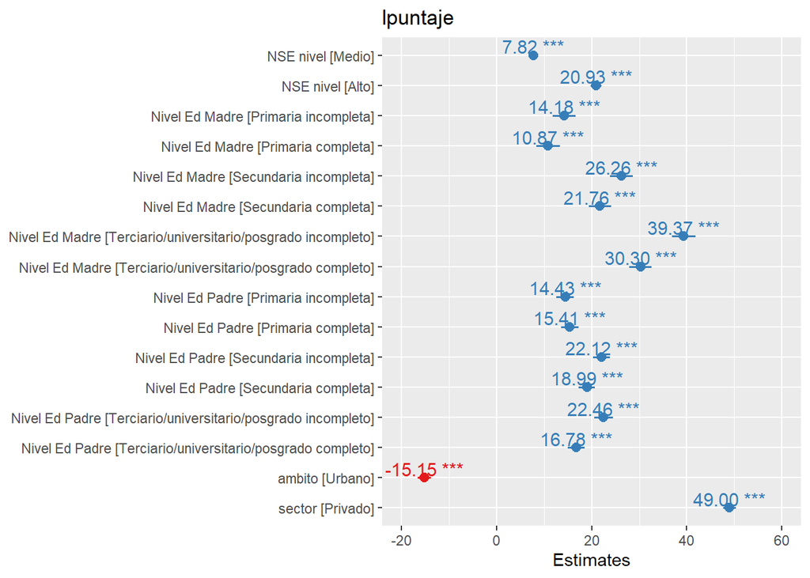

```r
library(sjPlot)

# Graficar efectos fijos
plot_model(mixto_intercept, type = "est", show.values = TRUE, value.offset = 0.3)
```

[figure not shown]

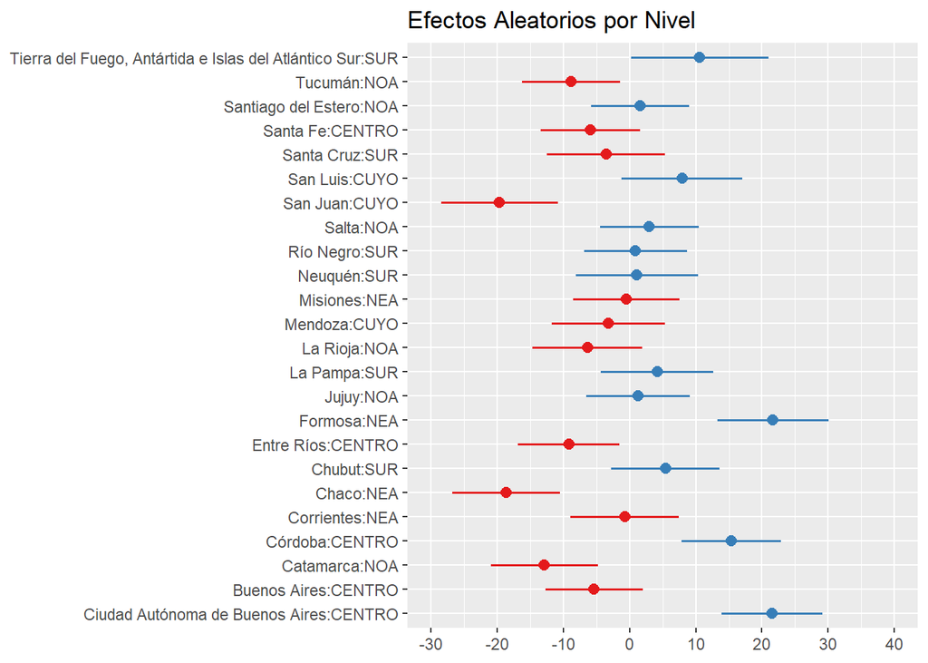

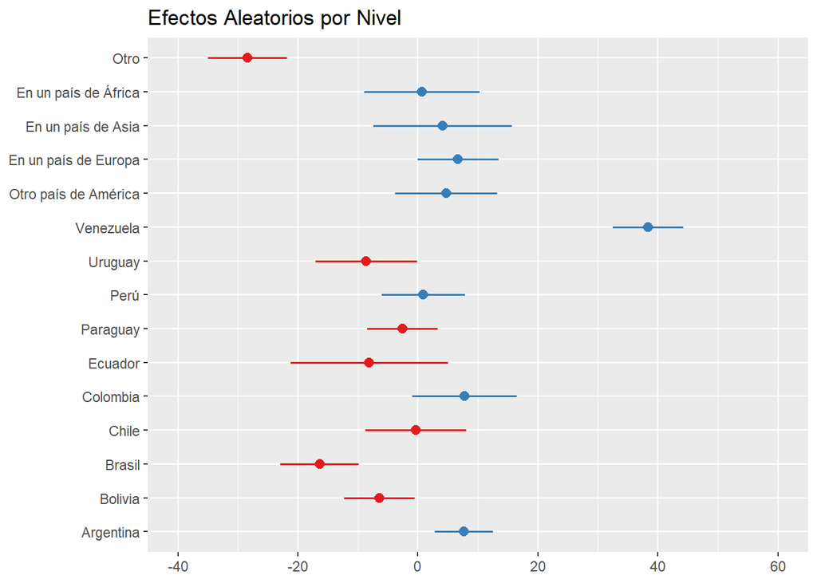

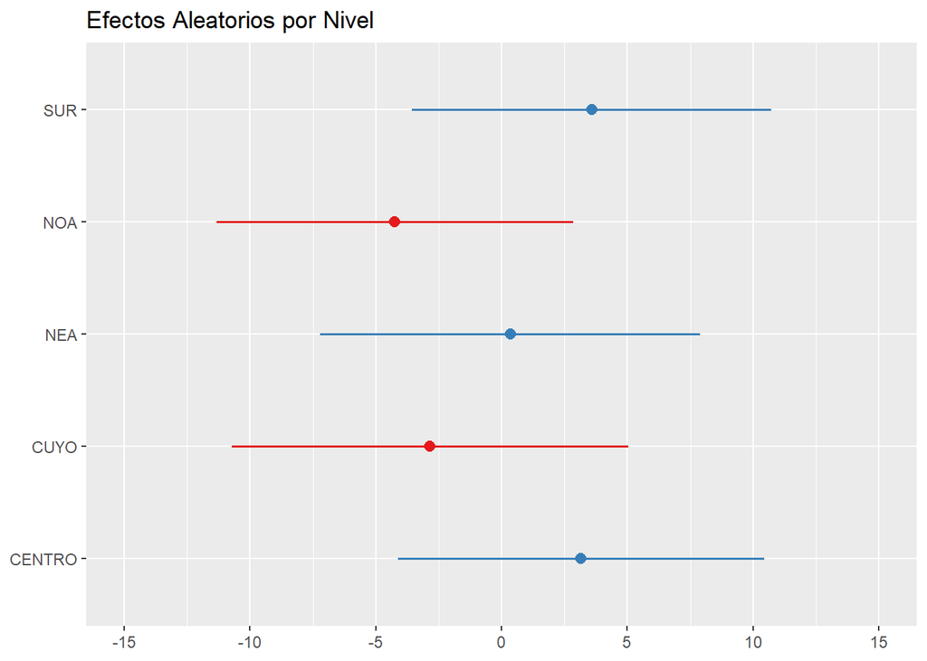

```r
# Graficar efectos aleatorios
plot_model(
  mixto_intercept,
  type = "re",
  title = "Efectos Aleatorios por Nivel"
)
```

## Supuestos del modelo

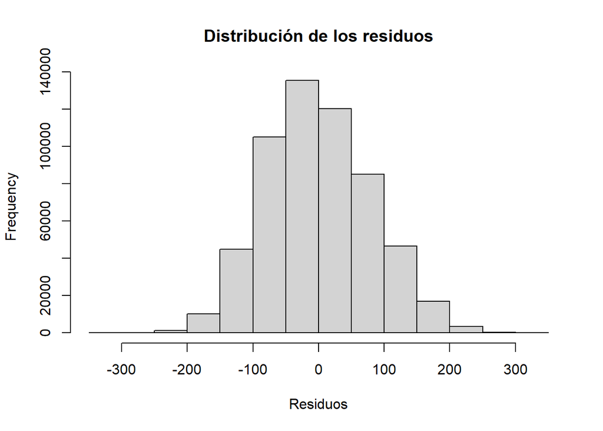

```r
#1. Normalidad en los Residuos
# Residuos del modelo
residuos <- residuals(mixto_intercept)

# Histograma de los residuos
hist(residuos, main = "Distribución de los residuos", xlab = "Residuos")
```

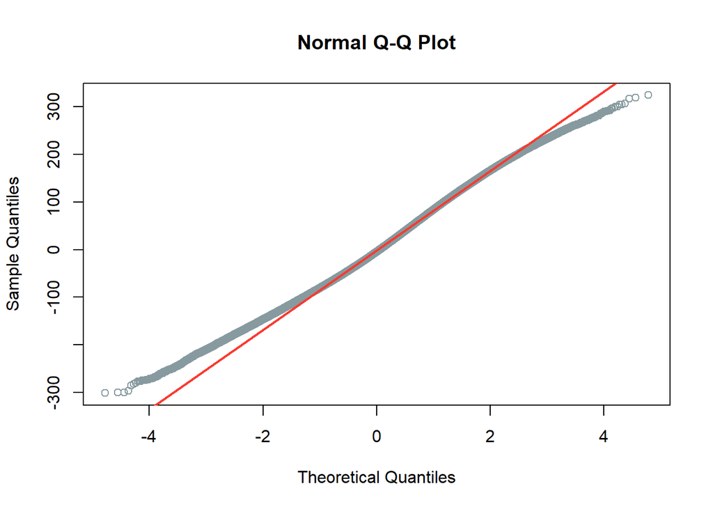

```r
# Q-Q plot para verificar normalidad
qqnorm(residuos, col = paleta_categoria[2])
qqline(residuos, col = paleta_categoria[1], lwd = 2)
```

Los residuos están cercanos a la normalidad.

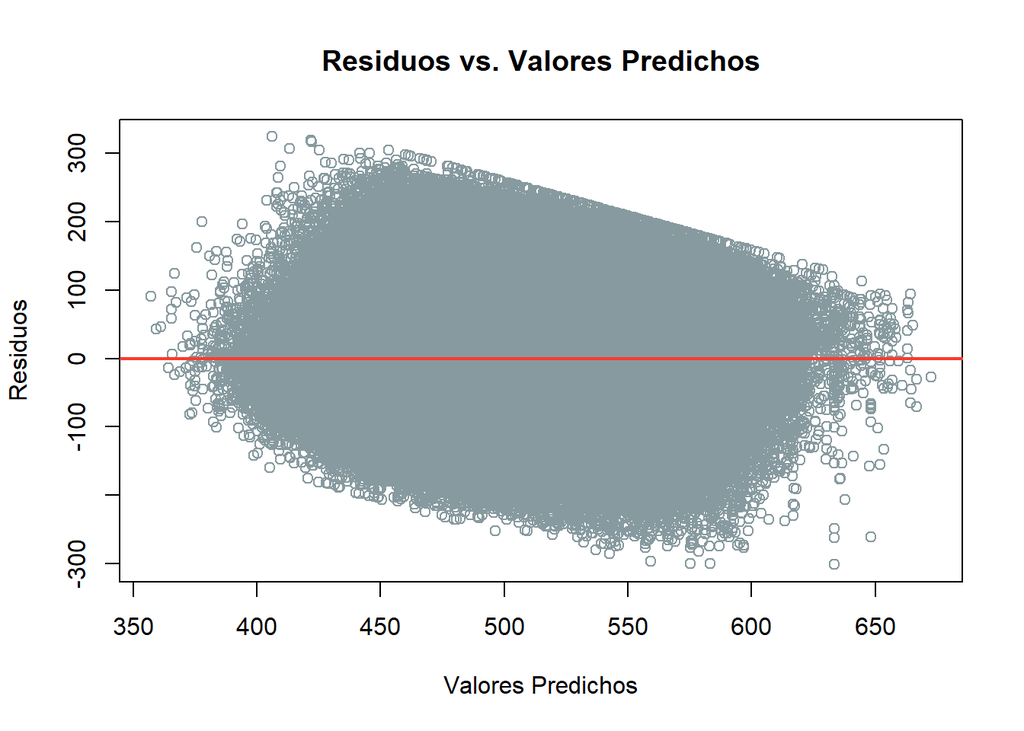

```r
#2. Homocedasticidad
predicciones <- predict(mixto_intercept)

# Gráfico de residuos vs. valores predichos
plot(predicciones, residuos,
     main = "Residuos vs. Valores Predichos",
     xlab = "Valores Predichos",
     ylab = "Residuos",
     col = paleta_categoria[2])
abline(h = 0, col = paleta_categoria[1], lwd = 2)
```

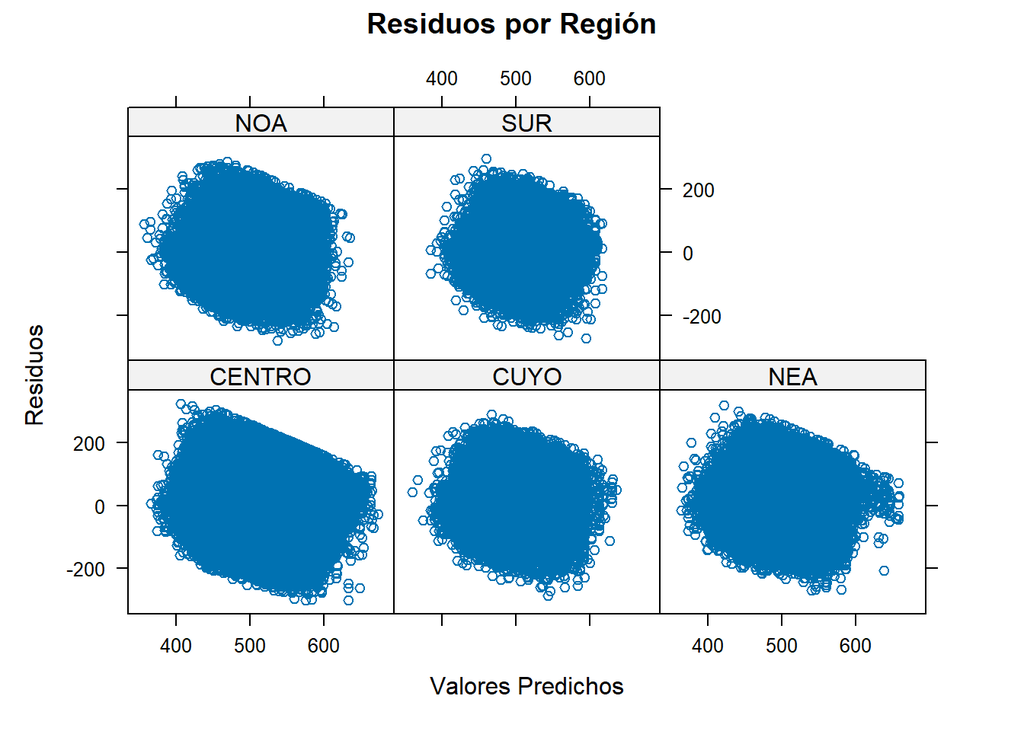

```r
#3. Supuesto de independencia de los residuos
library(lattice)

# Residuos vs predicciones para cada grupo

# 1. Por región
xyplot(residuos ~ predicciones | aprender$region,
       main = "Residuos por Región",
       xlab = "Valores Predichos",
       ylab = "Residuos",
       layout = c(3, 2))
```

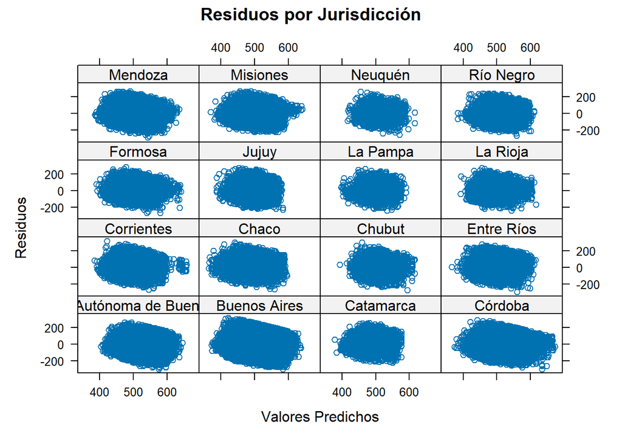

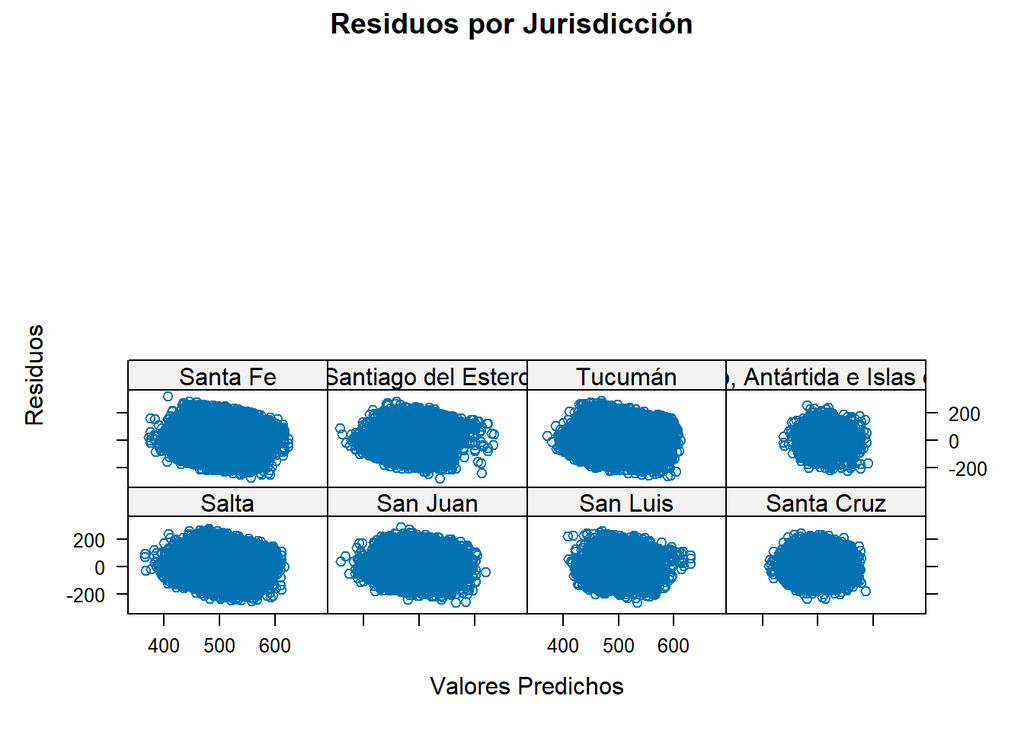

```r
# 2. Por jurisdicción
xyplot(residuos ~ predicciones | aprender$jurisdiccion,
       main = "Residuos por Jurisdicción",
       xlab = "Valores Predichos",
       ylab = "Residuos",
       layout = c(4, 4))
```

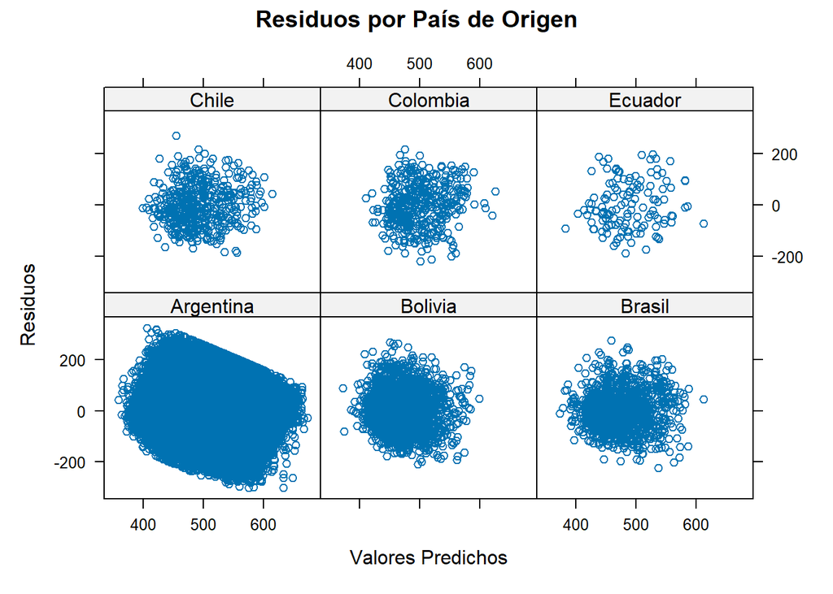

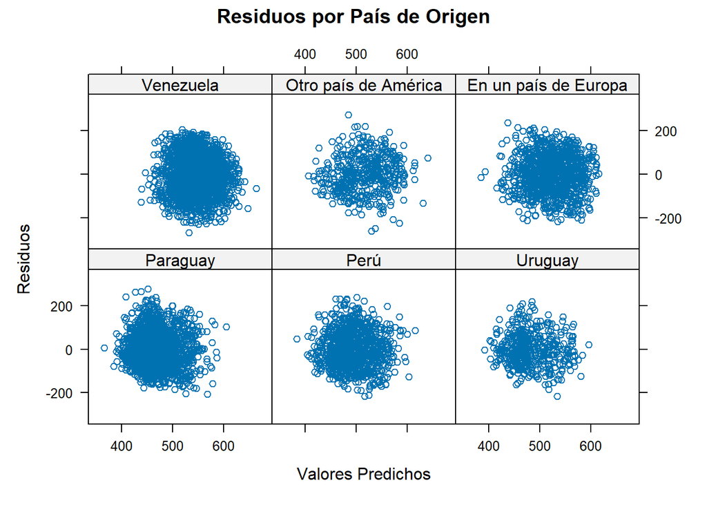

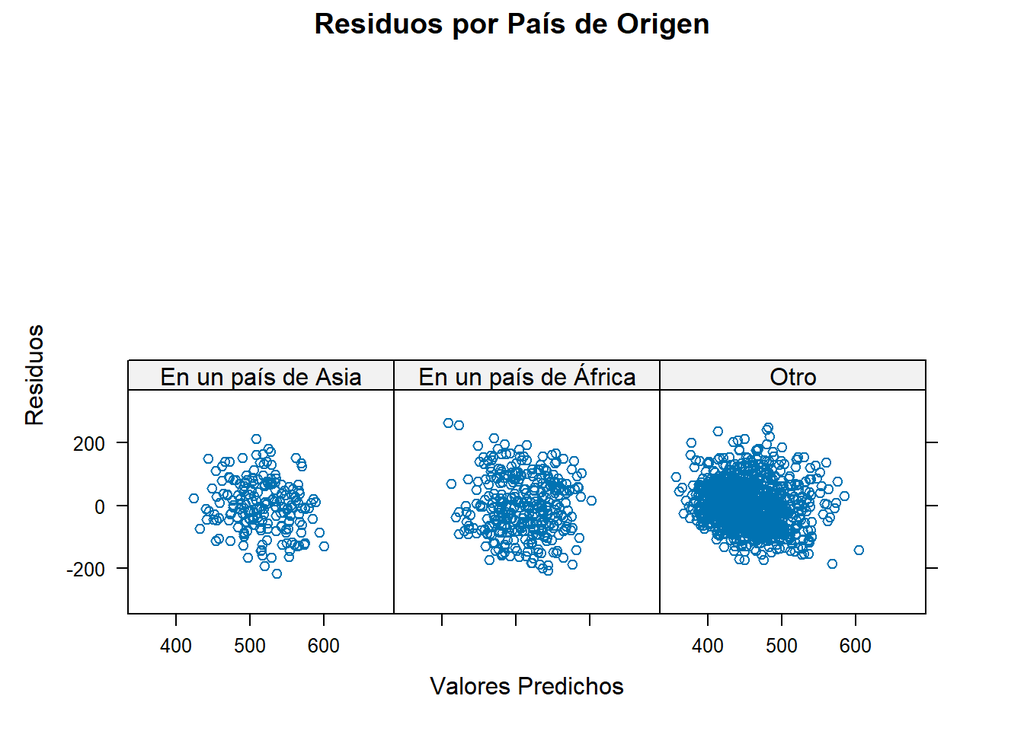

```r
# 3. Por país de origen
xyplot(residuos ~ predicciones | aprender$pais_origen,
       main = "Residuos por País de Origen",
       xlab = "Valores Predichos",
       ylab = "Residuos",
       layout = c(3, 2))
```

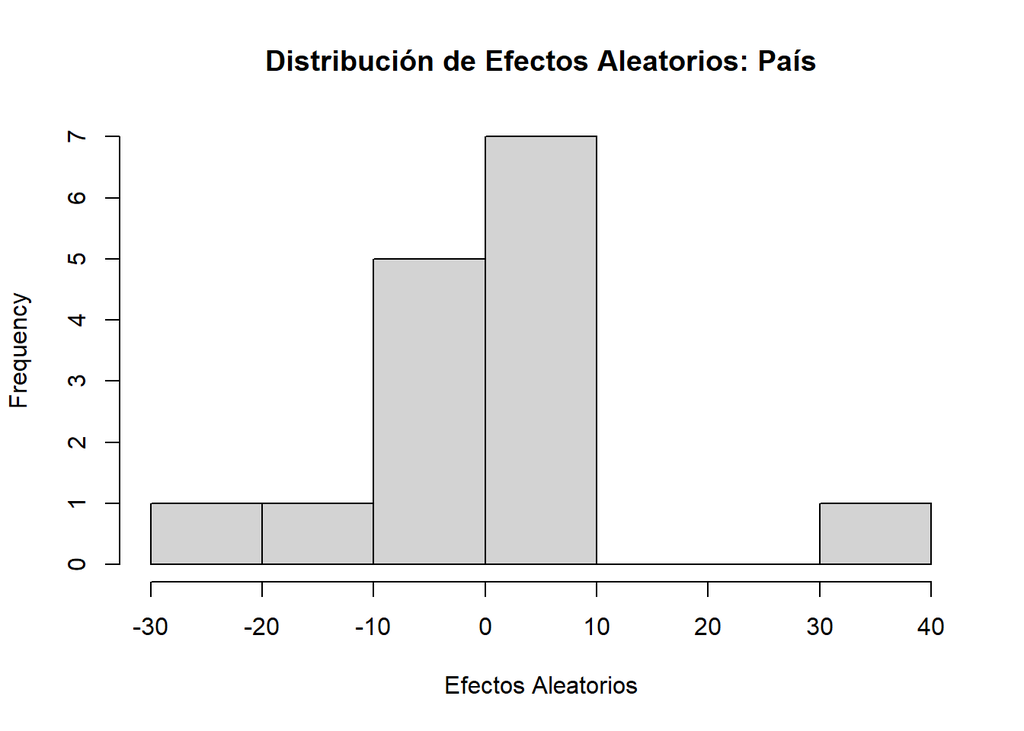

```r
#4. Supuesto de normalidad en los efectos aleatorios
# Extraer efectos aleatorios para todos los niveles
efectos <- ranef(mixto_intercept, condVar = TRUE)

# 1. Efectos aleatorios por país
efectos_pais <- efectos$pais_origen[[1]]
hist(efectos_pais, main = "Distribución de Efectos Aleatorios: País", xlab = "Efectos Aleatorios")
```

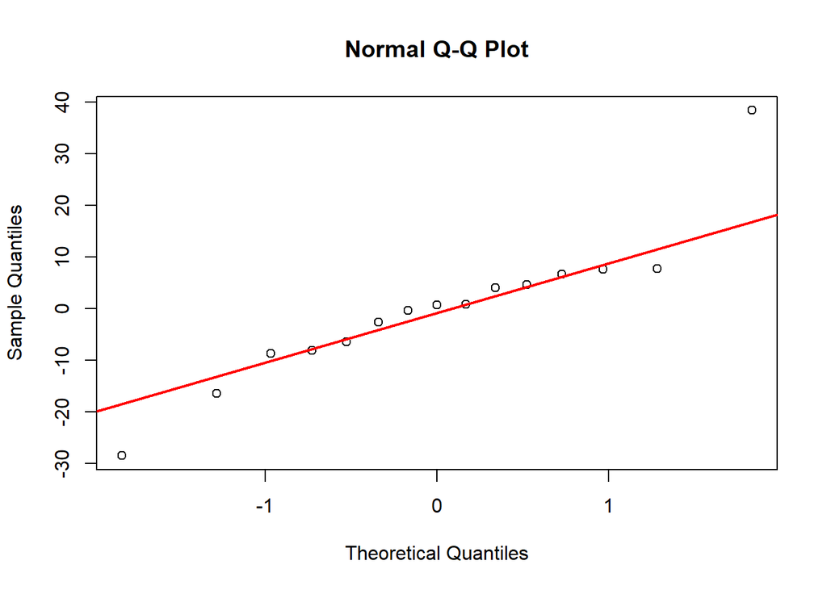

```r
qqnorm(efectos_pais)
qqline(efectos_pais, col = "red", lwd = 2)
```

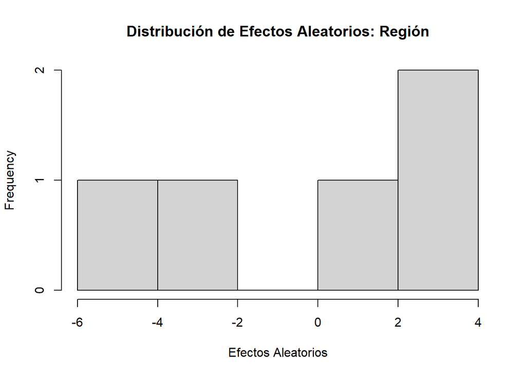

```r
# 2. Efectos aleatorios por región
efectos_region <- efectos$region[[1]]
hist(efectos_region, main = "Distribución de Efectos Aleatorios: Región", xlab = "Efectos Aleatorios")
```

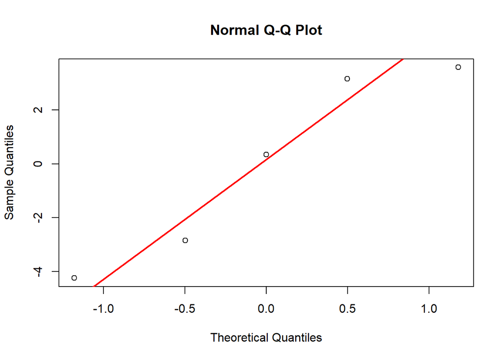

```r
qqnorm(efectos_region)
qqline(efectos_region, col = "red", lwd = 2)
```

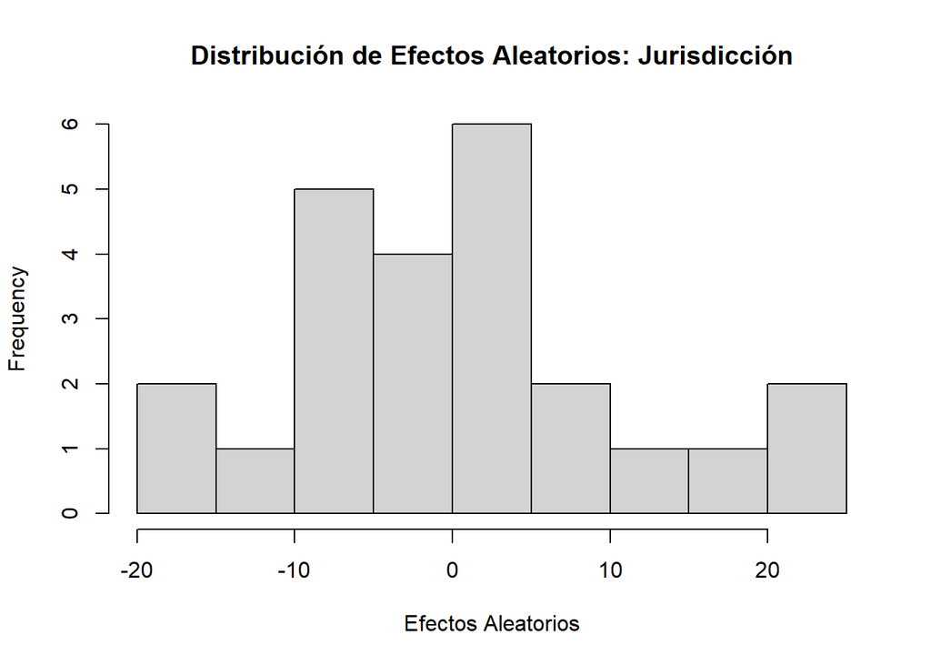

```r
# 3. Efectos aleatorios por jurisdicción
efectos_jurisdiccion <- efectos$`jurisdiccion:region`[[1]]
hist(efectos_jurisdiccion, main = "Distribución de Efectos Aleatorios: Jurisdicción", xlab = "Efectos Aleatorios")
```

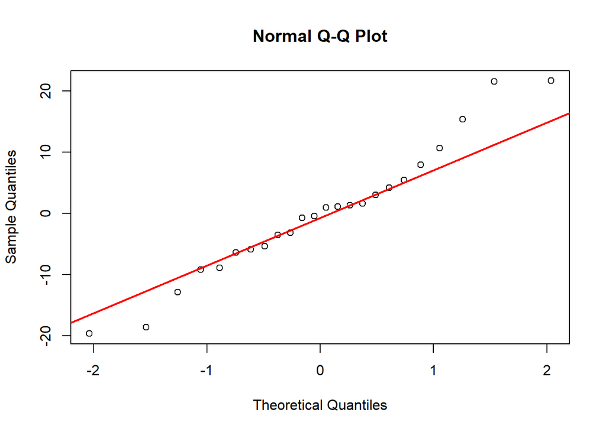

```r
qqnorm(efectos_jurisdiccion)
qqline(efectos_jurisdiccion, col = "red", lwd = 2)
```

A nivel país y jurisdicción, las desviaciones de normalidad no son críticas. A nivel región, el supuesto se cumple sin problemas significativos.

```r
#5.Supuesto de colinealidad en efectos fijos.

vif(mixto_intercept)
```

```
##                    GVIF Df GVIF^(1/(2*Df))
## NSE_nivel      1.501645  2        1.106985
## Nivel_Ed_Madre 2.596702  6        1.082767
## Nivel_Ed_Padre 2.627999  6        1.083849
## ambito         1.073965  1        1.036323
## sector         1.087848  1        1.043000
```

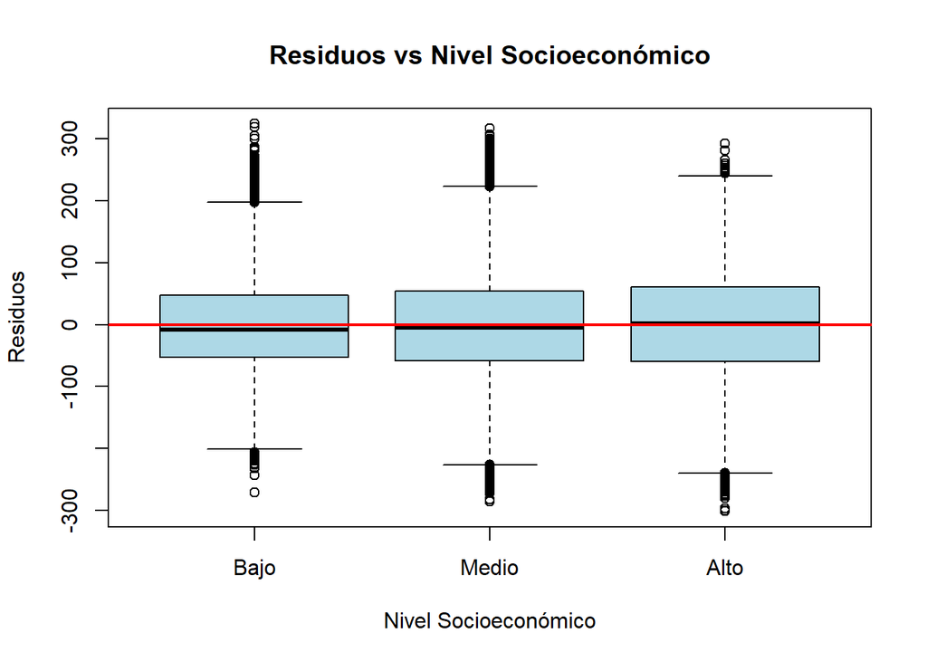

```r
#6. SUpuesto de Linealidad
boxplot(residuos ~ aprender$NSE_nivel,
        main = "Residuos vs Nivel Socioeconómico",
        xlab = "Nivel Socioeconómico",
        ylab = "Residuos",
        col = "lightblue")
abline(h = 0, col = "red", lwd = 2)
```

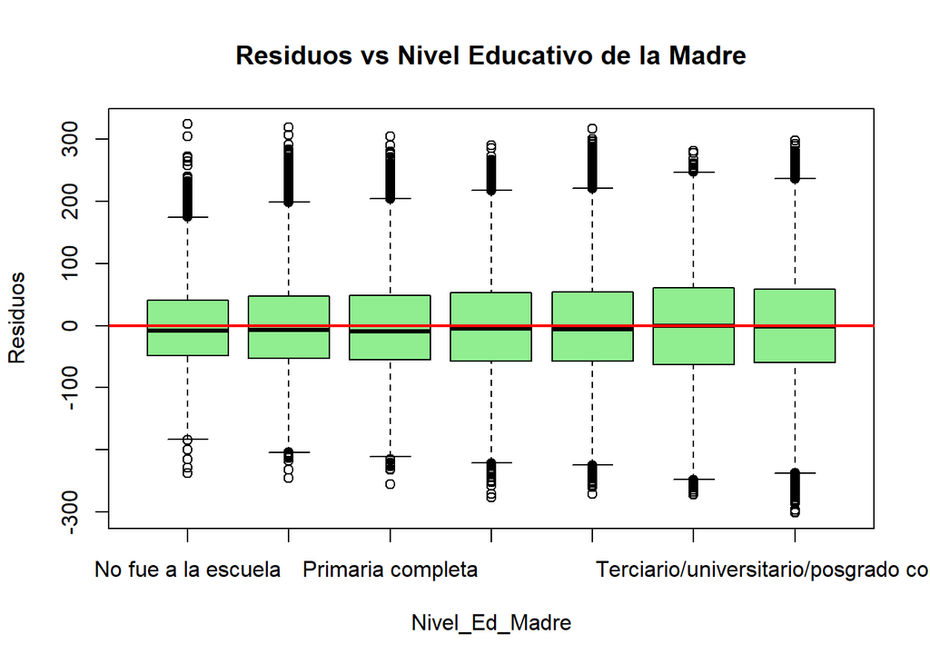

```r
boxplot(residuos ~ aprender$Nivel_Ed_Madre,
        main = "Residuos vs Nivel Educativo de la Madre",
        xlab = "Nivel_Ed_Madre",
        ylab = "Residuos",
        col = "lightgreen")
abline(h = 0, col = "red", lwd = 2)
```

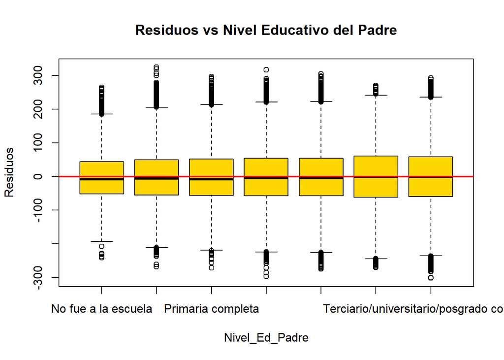

```r
boxplot(residuos ~ aprender$Nivel_Ed_Padre,
        main = "Residuos vs Nivel Educativo del Padre",
        xlab = "Nivel_Ed_Padre",
        ylab = "Residuos",
        col = "gold")
abline(h = 0, col = "red", lwd = 2)
```

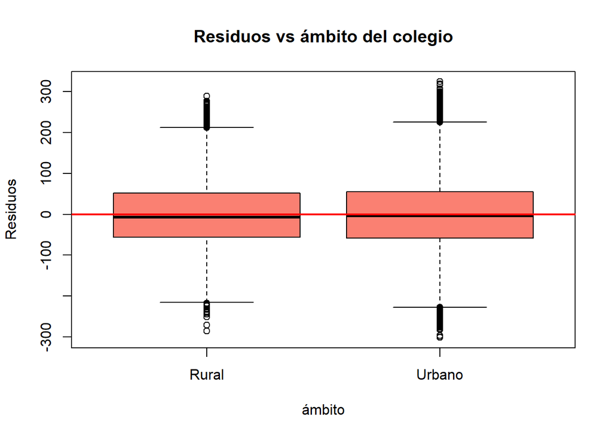

```r
boxplot(residuos ~ aprender$ambito,
        main = "Residuos vs ámbito del colegio",
        xlab = "ámbito",
        ylab = "Residuos",
        col = "salmon")
abline(h = 0, col = "red", lwd = 2)
```

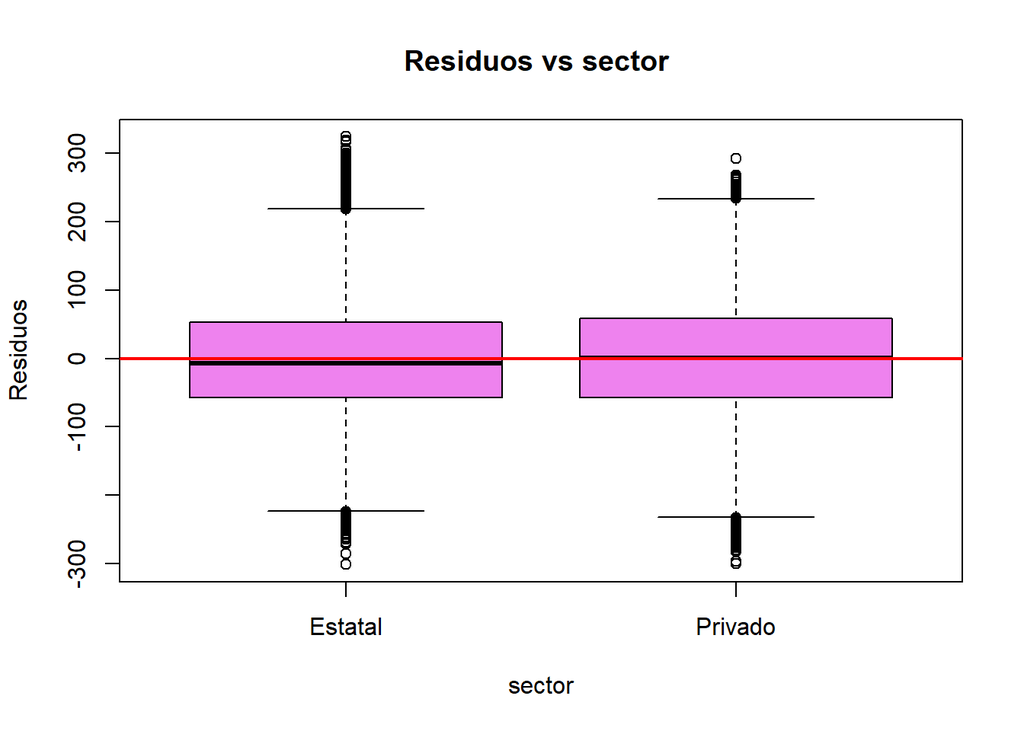

```r
boxplot(residuos ~ aprender$sector,
        main = "Residuos vs sector ",
        xlab = "sector",
        ylab = "Residuos",
        col = "violet")
abline(h = 0, col = "red", lwd = 2)
```

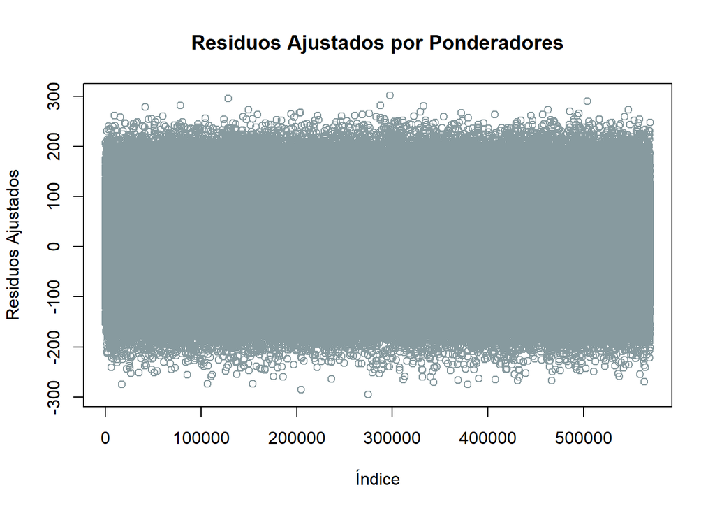

```r
#7. Supuesto de ponderación (ya que usamos peso)
# Residuos ajustados por ponderadores
ajustados <- residuos / sqrt(aprender$lpondera)
plot(ajustados, main = "Residuos Ajustados por Ponderadores", xlab = "Índice", ylab = "Residuos Ajustados",
     col = paleta_categoria[2])
```